# PHÂN TÍCH DỮ LIỆU KHẢO SÁT VĂN HÓA CHẤT LƯỢNG TRƯỜNG HỌC

**Đề tài:** Quản lí xây dựng văn hóa chất lượng (VHCL) tại các trường phổ thông — Nghiên cứu sinh Đặng Thị Kim Sơn, Khoa Quản lí Giáo dục, Trường ĐH Sư phạm TP.HCM.

**Dữ liệu:** N = 281 (GV người Việt, CBQL người Việt, GV người nước ngoài, CBQL người nước ngoài) tại 5 trường; thang Likert 6 mức (1 = Hoàn toàn không đồng ý → 6 = Hoàn toàn đồng ý); riêng SAT_O/SAT_J dùng thang hài lòng 5 mức.

**Nội dung phân tích:**

1. Làm sạch dữ liệu, mã hóa ngược item phủ định (COM4, RES4)
2. Thống kê mô tả mẫu khảo sát (nhân khẩu học)
3. Thống kê mô tả các biến quan sát
4. Độ tin cậy thang đo — Cronbach's Alpha
5. Phân tích nhân tố khám phá (EFA): KMO, Bartlett, PAF + Promax
6. Tính biến đại diện, kiểm tra phân phối
7. Phân tích tương quan Pearson
8. Kiểm định khác biệt trung bình (t-test, ANOVA)
9. Hồi quy bội (tiền đề của VHCL; kết quả của VHCL)
10. Mô hình đường dẫn (Path model H1–H6, semopy) + SEM đầy đủ 10b. PLS-SEM (plspm) — kiểm chứng variance-based cùng cấu trúc H1–H6
11. Phân tích trung gian (bootstrap)
12. Phân tích giá trị nền tảng VHCL (SHA3/SHA4 — câu hỏi nhiều lựa chọn)
13. Biểu đồ trực quan hóa kết quả (Alpha, EFA, path model, PLS-SEM, trung gian)

```python
# 1. Thư viện & nạp dữ liệu
import warnings; warnings.filterwarnings('ignore')
import numpy as np, pandas as pd
import matplotlib.pyplot as plt, seaborn as sns
from scipy import stats
import pingouin as pg
from factor_analyzer import FactorAnalyzer
from factor_analyzer.factor_analyzer import calculate_kmo, calculate_bartlett_sphericity
import json, os

# sklearn>=1.6 đổi force_all_finite -> ensure_all_finite; factor_analyzer 0.5.1 chưa cập nhật
import factor_analyzer.factor_analyzer as _fa_mod
import factor_analyzer.confirmatory_factor_analyzer as _cfa_mod
from sklearn.utils.validation import check_array as _sk_check_array
def _check_array_compat(*args, **kwargs):
    if 'force_all_finite' in kwargs and 'ensure_all_finite' not in kwargs:
        kwargs['ensure_all_finite'] = kwargs.pop('force_all_finite')
    return _sk_check_array(*args, **kwargs)
_fa_mod.check_array = _check_array_compat
_cfa_mod.check_array = _check_array_compat

plt.rcParams['figure.dpi'] = 110
OUT = 'ket_qua'; os.makedirs(OUT, exist_ok=True)
SUMMARY = {}

DATA = '../Cleaned_Data/281_PKS_ThongKe_Full_v1.3.xlsx'
df = pd.read_excel(DATA, sheet_name='Statistic')
df = df.rename(columns={'COM 4': 'COM4', **{f'SHA 4_{i}': f'SHA4_{i:02d}' for i in range(1, 25)}})
print('Kích thước dữ liệu:', df.shape)
print('Thiếu dữ liệu:', int(df.isna().sum().sum()))
```

```
Kích thước dữ liệu: (281, 150)
Thiếu dữ liệu: 0
```

```python
# 2. Mã hóa ngược item phủ định + định nghĩa cấu trúc thang đo
# Đối chiếu với BangThamChieu.pdf — "Bảng đối chiếu mã hóa và nguồn tham khảo"
# COM4 ("chưa thật sự gắn kết...") và RES4 ("không tạo ra sự khác biệt...") là item phủ định -> đảo: x' = 7 - x
df['COM4r'] = 7 - df['COM4']
df['RES4r'] = 7 - df['RES4']

CONSTRUCTS = {
    # --- Khoi CT-HT (Cau truc - Hinh thuc), 9 bien quan sat
    'NOR': ['NOR1','NOR2','NOR3'],
    'STR': ['STR1','STR2','STR3'],
    'OPE': ['OPE1','OPE2','OPE3'],
    # --- Khoi trung gian, 22 bien quan sat
    'LED': [f'LED{i}' for i in range(1,13)],
    'COL': [f'COL{i}' for i in range(1,7)],
    'PAR': [f'PAR{i}' for i in range(1,5)],
    # --- Khoi TL-TC (Tam ly - To chuc): tap the
    'TRU': [f'TRU{i}' for i in range(1,5)],
    'SHA': ['SHA1','SHA2'],          # SHA3/SHA4 la cau da lua chon -> xem muc 13
    # --- Khoi TL-TC: ca nhan
    'COM': ['COM1','COM2','COM3','COM4r'],
    'RES': ['RES1','RES2','RES3','RES4r'],
    'ENG': [f'ENG{i}' for i in range(1,5)],
    # --- Do luong VHCL bang cac khia canh tong the, 8 bien quan sat
    'GLO': [f'GLO{i}' for i in range(1,9)],
    # --- Cac bien ket qua, 28 bien quan sat
    'OCM': [f'OCM{i}' for i in range(1,4)],
    'SAT_O': [f'SAT_O{i}' for i in range(1,7)],
    'SAT_J': [f'SAT_J{i}' for i in range(1,5)],
    'WEG': [f'WEG{i}' for i in range(1,10)],
    'PRO': [f'PRO{i}' for i in range(1,7)],
}

# Ten thang do theo Bang tham chieu
TEN_VN = {
    'COM': 'Cam kết',
    'RES': 'Trách nhiệm',
    'ENG': 'Gắn kết',
    'SHA': 'Các giá trị',
    'TRU': 'Niềm tin',
    'NOR': 'Chuẩn mực',
    'STR': 'Chiến lược',
    'OPE': 'Hành động',
    'LED': 'Lãnh đạo',
    'COL': 'Giao tiếp',
    'PAR': 'Tham gia',
    'GLO': 'Các khía cạnh tổng thể',
    'SAT_O': 'Hài lòng với tổ chức',
    'SAT_J': 'Hài lòng với công việc',
    'WEG': 'Gắn kết công việc',
    'PRO': 'Phát triển chuyên môn',
    'OCM': 'Cam kết tổ chức',
}

# Phan khoi theo Bang tham chieu
BLOCKS = {
    'Yếu tố Tâm lý (TL) – Tổ chức (TC)': ['COM', 'RES', 'ENG', 'SHA', 'TRU'],
    'Yếu tố Cấu trúc (CT) – Hình thức (HT)': ['NOR', 'STR', 'OPE'],
    'Yếu tố trung gian kết nối TL–TC & CT–HT': ['LED', 'COL', 'PAR'],
    'Đo VHCL bằng các khía cạnh tổng thể': ['GLO'],
    'Các biến kết quả': ['SAT_O', 'SAT_J', 'WEG', 'PRO', 'OCM'],
}
BLOCK_OF = {c: b for b, lst in BLOCKS.items() for c in lst}
LEVEL_OF = {
    'COM': 'Cá nhân',
    'RES': 'Cá nhân',
    'ENG': 'Cá nhân',
    'SHA': 'Tập thể',
    'TRU': 'Tập thể',
}

# Nguon thang do theo Bang tham chieu
SOURCES = {
    'COM': 'Jackson (2004); Sattler et al. (2016); Hildesheim & Sonntag (2019)',
    'RES': 'Jackson (2004); Sattler et al. (2016); Hildesheim & Sonntag (2019)',
    'ENG': 'Jackson (2004); Sattler et al. (2016); Hildesheim & Sonntag (2019)',
    'SHA': 'Sattler et al. (2016); Hildesheim & Sonntag (2019)',
    'TRU': 'Zeitz et al. (1997); Hildesheim & Sonntag (2019)',
    'NOR': 'Sattler et al. (2016); Verschueren et al. (2023)',
    'STR': 'Sattler et al. (2016); Verschueren et al. (2023)',
    'OPE': 'Sattler et al. (2016); Verschueren et al. (2023)',
    'LED': 'Heinitz & Rowold (2007); Hildesheim & Sonntag (2019)',
    'COL': 'Brodbeck et al. (2000); Hildesheim & Sonntag (2019)',
    'PAR': 'Staufenbiel & Hartz (2000); Hildesheim & Sonntag (2019)',
    'GLO': 'Sattler et al. (2016); Hildesheim & Sonntag (2019)',
    'SAT_O': 'Hildesheim & Sonntag (2019)',
    'SAT_J': 'Hildesheim & Sonntag (2019)',
    'WEG': 'Schaufeli et al. (2006)',
    'PRO': 'Mourao et al. (2022)',
    'OCM': 'Sattler et al. (2016)',
}

# So item theo thiet ke (Bang tham chieu)
N_DESIGN = {
    'COM': 4,
    'RES': 4,
    'ENG': 4,
    'SHA': 4,
    'TRU': 4,
    'NOR': 3,
    'STR': 3,
    'OPE': 3,
    'LED': 12,
    'COL': 6,
    'PAR': 4,
    'GLO': 8,
    'SAT_O': 6,
    'SAT_J': 4,
    'WEG': 9,
    'PRO': 6,
    'OCM': 3,
}

N_TK = sum(N_DESIGN.values())
N_PHAN_TICH = sum(len(v) for v in CONSTRUCTS.values())

scale_ref = pd.DataFrame([{
    'Thang đo': c, 'Tên': TEN_VN[c], 'Khối': BLOCK_OF[c],
    'Cấp độ': LEVEL_OF.get(c, ''), 'Số item (thiết kế)': N_DESIGN[c],
    'Số item (phân tích)': len(CONSTRUCTS[c]), 'Nguồn': SOURCES[c],
} for c in CONSTRUCTS])
scale_ref.to_csv(f'{OUT}/bang_thang_do_tham_chieu.csv', index=False, encoding='utf-8-sig')
SUMMARY['scale_reference'] = scale_ref.to_dict('records')
SUMMARY['n_items'] = {'design': N_TK, 'analysis': N_PHAN_TICH}

print(f"Số thang đo: {len(CONSTRUCTS)} | Biến quan sát đưa vào phân tích: {N_PHAN_TICH} "
      f"| Theo bảng tham chiếu: {N_TK} ")
print(f"Ghi chú: SHA3 và SHA4 trong bảng tham chiếu là câu hỏi nhiều lựa chọn (24 phương án),\n"
      f"không phải thang Likert nên không đưa vào Cronbach/EFA/SEM; được phân tích riêng ở mục 13.\n"
      f"Do đó {N_TK} biến thiết kế tương ứng {N_PHAN_TICH} biến quan sát Likert trong mô hình.")
scale_ref
```

```
Số thang đo: 17 | Biến quan sát đưa vào phân tích: 85 | Theo bảng tham chiếu: 87
Ghi chú: SHA3 và SHA4 trong bảng tham chiếu là câu hỏi nhiều lựa chọn (24 phương án),
không phải thang Likert nên không đưa vào Cronbach/EFA/SEM; được phân tích riêng ở mục 13.
Do đó 87 biến thiết kế tương ứng 85 biến quan sát Likert trong mô hình.
```

|  | Thang đo | Tên | Khối | Cấp độ | Số item (thiết kế) | Số item (phân tích) | Nguồn |
| --- | --- | --- | --- | --- | --- | --- | --- |
| 0 | NOR | Chuẩn mực | Yếu tố Cấu trúc (CT) – Hình thức (HT) |  | 3 | 3 | Sattler et al. (2016); Verschueren et al. (2023) |
| 1 | STR | Chiến lược | Yếu tố Cấu trúc (CT) – Hình thức (HT) |  | 3 | 3 | Sattler et al. (2016); Verschueren et al. (2023) |
| 2 | OPE | Hành động | Yếu tố Cấu trúc (CT) – Hình thức (HT) |  | 3 | 3 | Sattler et al. (2016); Verschueren et al. (2023) |
| 3 | LED | Lãnh đạo | Yếu tố trung gian kết nối TL–TC & CT–HT |  | 12 | 12 | Heinitz & Rowold (2007); Hildesheim & Sonntag ... |
| 4 | COL | Giao tiếp | Yếu tố trung gian kết nối TL–TC & CT–HT |  | 6 | 6 | Brodbeck et al. (2000); Hildesheim & Sonntag (... |
| 5 | PAR | Tham gia | Yếu tố trung gian kết nối TL–TC & CT–HT |  | 4 | 4 | Staufenbiel & Hartz (2000); Hildesheim & Sonnt... |
| 6 | TRU | Niềm tin | Yếu tố Tâm lý (TL) – Tổ chức (TC) | Tập thể | 4 | 4 | Zeitz et al. (1997); Hildesheim & Sonntag (2019) |
| 7 | SHA | Các giá trị | Yếu tố Tâm lý (TL) – Tổ chức (TC) | Tập thể | 4 | 2 | Sattler et al. (2016); Hildesheim & Sonntag (2... |
| 8 | COM | Cam kết | Yếu tố Tâm lý (TL) – Tổ chức (TC) | Cá nhân | 4 | 4 | Jackson (2004); Sattler et al. (2016); Hildesh... |
| 9 | RES | Trách nhiệm | Yếu tố Tâm lý (TL) – Tổ chức (TC) | Cá nhân | 4 | 4 | Jackson (2004); Sattler et al. (2016); Hildesh... |
| 10 | ENG | Gắn kết | Yếu tố Tâm lý (TL) – Tổ chức (TC) | Cá nhân | 4 | 4 | Jackson (2004); Sattler et al. (2016); Hildesh... |
| 11 | GLO | Các khía cạnh tổng thể | Đo VHCL bằng các khía cạnh tổng thể |  | 8 | 8 | Sattler et al. (2016); Hildesheim & Sonntag (2... |
| 12 | OCM | Cam kết tổ chức | Các biến kết quả |  | 3 | 3 | Sattler et al. (2016) |
| 13 | SAT_O | Hài lòng với tổ chức | Các biến kết quả |  | 6 | 6 | Hildesheim & Sonntag (2019) |
| 14 | SAT_J | Hài lòng với công việc | Các biến kết quả |  | 4 | 4 | Hildesheim & Sonntag (2019) |
| 15 | WEG | Gắn kết công việc | Các biến kết quả |  | 9 | 9 | Schaufeli et al. (2006) |
| 16 | PRO | Phát triển chuyên môn | Các biến kết quả |  | 6 | 6 | Mourao et al. (2022) |

## 3. Thống kê mô tả mẫu khảo sát

```python
LABELS = {
 'Nhom_CB': {1:'GV người Việt', 2:'GV người nước ngoài', 3:'CBQL người Việt', 4:'CBQL người nước ngoài'},
 'Gioi_tinh': {0:'Nam', 1:'Nữ'},
 'Do_tuoi': {1:'Dưới 30', 2:'30–39', 3:'40–49', 4:'50–59', 5:'Từ 60 trở lên'},
 'Bang_cap': {1:'Cử nhân', 2:'Thạc sĩ', 3:'Tiến sĩ', 9:'Khác'},
 'Hop_dong': {1:'Xác định thời hạn', 2:'Không xác định thời hạn', 3:'Khác'},
 'Thoi_gian_cong_tac': {1:'Dưới 3 năm', 2:'3–dưới 8 năm', 3:'8–dưới 15 năm', 4:'15–dưới 25 năm', 5:'Từ 25 năm trở lên'},
 'Truong': {1:'Trường 1', 2:'Trường 2', 3:'Trường 3', 4:'Trường 4', 5:'Trường 5'},
}
rows = []
for var, mp in LABELS.items():
    vc = df[var].value_counts().sort_index()
    for k, n in vc.items():
        rows.append({'Đặc điểm': var, 'Nhóm': mp.get(k, k), 'Số lượng': int(n), 'Tỷ lệ (%)': round(100*n/len(df), 1)})
demo = pd.DataFrame(rows)
demo.to_csv(f'{OUT}/bang_mo_ta_mau.csv', index=False, encoding='utf-8-sig')
SUMMARY['demographics'] = rows
demo
```

|  | Đặc điểm | Nhóm | Số lượng | Tỷ lệ (%) |
| --- | --- | --- | --- | --- |
| 0 | Nhom_CB | GV người Việt | 210 | 74.7 |
| 1 | Nhom_CB | GV người nước ngoài | 26 | 9.3 |
| 2 | Nhom_CB | CBQL người Việt | 35 | 12.5 |
| 3 | Nhom_CB | CBQL người nước ngoài | 10 | 3.6 |
| 4 | Gioi_tinh | Nam | 72 | 25.6 |
| 5 | Gioi_tinh | Nữ | 209 | 74.4 |
| 6 | Do_tuoi | Dưới 30 | 104 | 37.0 |
| 7 | Do_tuoi | 30–39 | 125 | 44.5 |
| 8 | Do_tuoi | 40–49 | 44 | 15.7 |
| 9 | Do_tuoi | 50–59 | 7 | 2.5 |
| 10 | Do_tuoi | Từ 60 trở lên | 1 | 0.4 |
| 11 | Bang_cap | Cử nhân | 194 | 69.0 |
| 12 | Bang_cap | Thạc sĩ | 78 | 27.8 |
| 13 | Bang_cap | Tiến sĩ | 8 | 2.8 |
| 14 | Bang_cap | Khác | 1 | 0.4 |
| 15 | Hop_dong | Xác định thời hạn | 129 | 45.9 |
| 16 | Hop_dong | Không xác định thời hạn | 148 | 52.7 |
| 17 | Hop_dong | Khác | 4 | 1.4 |
| 18 | Thoi_gian_cong_tac | Dưới 3 năm | 54 | 19.2 |
| 19 | Thoi_gian_cong_tac | 3–dưới 8 năm | 103 | 36.7 |
| 20 | Thoi_gian_cong_tac | 8–dưới 15 năm | 70 | 24.9 |
| 21 | Thoi_gian_cong_tac | 15–dưới 25 năm | 43 | 15.3 |
| 22 | Thoi_gian_cong_tac | Từ 25 năm trở lên | 11 | 3.9 |
| 23 | Truong | Trường 1 | 52 | 18.5 |
| 24 | Truong | Trường 2 | 55 | 19.6 |
| 25 | Truong | Trường 3 | 55 | 19.6 |
| 26 | Truong | Trường 4 | 63 | 22.4 |
| 27 | Truong | Trường 5 | 56 | 19.9 |

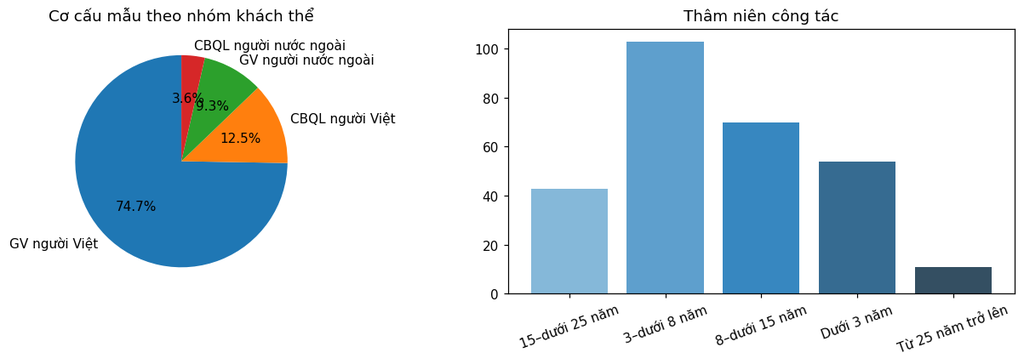

```python
# Biểu đồ cơ cấu mẫu
fig, axes = plt.subplots(1, 2, figsize=(12, 4))
d1 = df['Nhom_CB'].map(LABELS['Nhom_CB']).value_counts()
axes[0].pie(d1, labels=d1.index, autopct='%1.1f%%', startangle=90)
axes[0].set_title('Cơ cấu mẫu theo nhóm khách thể')
d2 = df['Thoi_gian_cong_tac'].map(LABELS['Thoi_gian_cong_tac']).value_counts().sort_index()
axes[1].bar(d2.index, d2.values, color=sns.color_palette('Blues_d', len(d2)))
axes[1].set_title('Thâm niên công tác'); axes[1].tick_params(axis='x', rotation=20)
plt.tight_layout(); plt.savefig(f'{OUT}/hinh_co_cau_mau.png', bbox_inches='tight'); plt.show()
```

## 4. Thống kê mô tả biến quan sát & thang đo

```python
all_items = [i for v in CONSTRUCTS.values() for i in v]
desc = df[all_items].agg(['mean','std','min','max','skew','kurt']).T.round(3)
desc.columns = ['Trung bình','Độ lệch chuẩn','Min','Max','Skewness','Kurtosis']
desc.to_csv(f'{OUT}/bang_mo_ta_bien_quan_sat.csv', encoding='utf-8-sig')
print('|Skewness| > 2:', list(desc.index[desc['Skewness'].abs() > 2]))
print('|Kurtosis| > 7:', list(desc.index[desc['Kurtosis'].abs() > 7]))
desc.head(15)
```

```
|Skewness| > 2: []
|Kurtosis| > 7: []
```

|  | Trung bình | Độ lệch chuẩn | Min | Max | Skewness | Kurtosis |
| --- | --- | --- | --- | --- | --- | --- |
| NOR1 | 4.694 | 1.213 | 1.0 | 6.0 | -1.174 | 1.113 |
| NOR2 | 4.577 | 1.190 | 1.0 | 6.0 | -1.118 | 1.070 |
| NOR3 | 4.591 | 1.165 | 1.0 | 6.0 | -1.163 | 1.209 |
| STR1 | 4.413 | 1.296 | 1.0 | 6.0 | -0.823 | -0.004 |
| STR2 | 4.637 | 1.209 | 1.0 | 6.0 | -1.119 | 1.080 |
| STR3 | 4.530 | 1.210 | 1.0 | 6.0 | -0.900 | 0.410 |
| OPE1 | 4.584 | 1.156 | 1.0 | 6.0 | -0.952 | 0.626 |
| OPE2 | 4.719 | 1.211 | 1.0 | 6.0 | -1.219 | 1.428 |
| OPE3 | 4.641 | 1.208 | 1.0 | 6.0 | -1.043 | 1.058 |
| LED1 | 4.829 | 0.974 | 1.0 | 6.0 | -1.332 | 2.674 |
| LED2 | 4.498 | 1.036 | 1.0 | 6.0 | -0.938 | 0.974 |
| LED3 | 4.633 | 1.064 | 1.0 | 6.0 | -1.391 | 2.625 |
| LED4 | 4.669 | 1.245 | 1.0 | 6.0 | -1.273 | 1.397 |
| LED5 | 4.794 | 1.262 | 1.0 | 6.0 | -1.323 | 1.381 |
| LED6 | 4.680 | 1.203 | 1.0 | 6.0 | -1.272 | 1.472 |

## 5. Độ tin cậy thang đo — Cronbach's Alpha

Tiêu chuẩn: α ≥ 0,70 (chấp nhận ≥ 0,60); tương quan biến–tổng hiệu chỉnh (CITC) ≥ 0,30.

```python
def cronbach_detail(data, items):
    X = data[items].dropna()
    k = len(items)
    alpha = pg.cronbach_alpha(data=X)[0]
    out = []
    for it in items:
        rest = X[[c for c in items if c != it]].sum(axis=1)
        citc = X[it].corr(rest)
        a_del = pg.cronbach_alpha(data=X[[c for c in items if c != it]])[0] if k > 2 else np.nan
        out.append({'Item': it, 'CITC': round(citc, 3), 'Alpha nếu loại biến': round(a_del, 3) if not np.isnan(a_del) else '—'})
    return alpha, pd.DataFrame(out)

alpha_rows, item_tables = [], {}
for c, items in CONSTRUCTS.items():
    a, tab = cronbach_detail(df, items)
    item_tables[c] = tab
    min_citc = tab['CITC'].min()
    alpha_rows.append({'Thang đo': c, 'Tên': TEN_VN[c], 'Khối': BLOCK_OF[c], 'Số item': len(items),
                       'Cronbach Alpha': round(a, 3), 'CITC nhỏ nhất': round(min_citc, 3),
                       'Đánh giá': 'Tốt' if a >= .8 else ('Đạt' if a >= .7 else ('Chấp nhận' if a >= .6 else 'Không đạt'))})
alpha_df = pd.DataFrame(alpha_rows)
alpha_df.to_csv(f'{OUT}/bang_cronbach_alpha.csv', index=False, encoding='utf-8-sig')
SUMMARY['cronbach'] = alpha_df.to_dict('records')
alpha_df
```

|  | Thang đo | Tên | Khối | Số item | Cronbach Alpha | CITC nhỏ nhất | Đánh giá |
| --- | --- | --- | --- | --- | --- | --- | --- |
| 0 | NOR | Chuẩn mực | Yếu tố Cấu trúc (CT) – Hình thức (HT) | 3 | 0.938 | 0.852 | Tốt |
| 1 | STR | Chiến lược | Yếu tố Cấu trúc (CT) – Hình thức (HT) | 3 | 0.909 | 0.780 | Tốt |
| 2 | OPE | Hành động | Yếu tố Cấu trúc (CT) – Hình thức (HT) | 3 | 0.889 | 0.759 | Tốt |
| 3 | LED | Lãnh đạo | Yếu tố trung gian kết nối TL–TC & CT–HT | 12 | 0.966 | 0.597 | Tốt |
| 4 | COL | Giao tiếp | Yếu tố trung gian kết nối TL–TC & CT–HT | 6 | 0.909 | 0.604 | Tốt |
| 5 | PAR | Tham gia | Yếu tố trung gian kết nối TL–TC & CT–HT | 4 | 0.759 | 0.499 | Đạt |
| 6 | TRU | Niềm tin | Yếu tố Tâm lý (TL) – Tổ chức (TC) | 4 | 0.831 | 0.571 | Tốt |
| 7 | SHA | Các giá trị | Yếu tố Tâm lý (TL) – Tổ chức (TC) | 2 | 0.848 | 0.736 | Tốt |
| 8 | COM | Cam kết | Yếu tố Tâm lý (TL) – Tổ chức (TC) | 4 | 0.574 | 0.236 | Không đạt |
| 9 | RES | Trách nhiệm | Yếu tố Tâm lý (TL) – Tổ chức (TC) | 4 | 0.527 | 0.211 | Không đạt |
| 10 | ENG | Gắn kết | Yếu tố Tâm lý (TL) – Tổ chức (TC) | 4 | 0.758 | 0.532 | Đạt |
| 11 | GLO | Các khía cạnh tổng thể | Đo VHCL bằng các khía cạnh tổng thể | 8 | 0.947 | 0.749 | Tốt |
| 12 | OCM | Cam kết tổ chức | Các biến kết quả | 3 | 0.857 | 0.710 | Tốt |
| 13 | SAT_O | Hài lòng với tổ chức | Các biến kết quả | 6 | 0.900 | 0.467 | Tốt |
| 14 | SAT_J | Hài lòng với công việc | Các biến kết quả | 4 | 0.847 | 0.610 | Tốt |
| 15 | WEG | Gắn kết công việc | Các biến kết quả | 9 | 0.890 | 0.406 | Tốt |
| 16 | PRO | Phát triển chuyên môn | Các biến kết quả | 6 | 0.832 | 0.544 | Tốt |

```python
# Chi tiết item–tổng của các thang đo có CITC thấp (< .30) nếu có
for c, tab in item_tables.items():
    if (tab['CITC'] < .30).any():
        print('---', c, TEN_VN[c]); print(tab.to_string(index=False))
```

```
--- COM Cam kết
 Item  CITC  Alpha nếu loại biến
 COM1 0.539                0.416
 COM2 0.531                0.428
 COM3 0.383                0.490
COM4r 0.236                0.753
--- RES Trách nhiệm
 Item  CITC  Alpha nếu loại biến
 RES1 0.428                0.360
 RES2 0.512                0.318
 RES3 0.232                0.520
RES4r 0.211                0.632
```

### Hiệu chỉnh thang đo

Theo tiêu chuẩn CITC ≥ 0,30 (Nunnally & Bernstein, 1994), các item có CITC thấp bị loại và thang đo được tính lại. Đây là bước chuẩn trước khi vào EFA.

```python
# Loại item có CITC < .30 (thường là item phủ định COM4r, RES4r) và tính lại Alpha
dropped = []
for c in list(CONSTRUCTS):
    tab = item_tables[c]
    bad = list(tab.loc[tab['CITC'] < .30, 'Item'])
    if bad and len(CONSTRUCTS[c]) - len(bad) >= 2:
        CONSTRUCTS[c] = [i for i in CONSTRUCTS[c] if i not in bad]
        dropped += bad
print('Item bị loại:', dropped)
alpha_rows2 = []
for c, items in CONSTRUCTS.items():
    a, tab = cronbach_detail(df, items)
    item_tables[c] = tab
    alpha_rows2.append({'Thang đo': c, 'Tên': TEN_VN[c], 'Số item': len(items),
                        'Cronbach Alpha': round(a, 3), 'CITC nhỏ nhất': round(tab['CITC'].min(), 3),
                        'Đánh giá': 'Tốt' if a >= .8 else ('Đạt' if a >= .7 else ('Chấp nhận' if a >= .6 else 'Không đạt'))})
alpha2_df = pd.DataFrame(alpha_rows2)
alpha2_df.to_csv(f'{OUT}/bang_cronbach_alpha_sau_hieu_chinh.csv', index=False, encoding='utf-8-sig')
SUMMARY['cronbach_refined'] = alpha2_df.to_dict('records')
SUMMARY['dropped_items'] = dropped
alpha2_df
```

```
Item bị loại: ['COM4r', 'RES3', 'RES4r']
```

|  | Thang đo | Tên | Số item | Cronbach Alpha | CITC nhỏ nhất | Đánh giá |
| --- | --- | --- | --- | --- | --- | --- |
| 0 | NOR | Chuẩn mực | 3 | 0.938 | 0.852 | Tốt |
| 1 | STR | Chiến lược | 3 | 0.909 | 0.780 | Tốt |
| 2 | OPE | Hành động | 3 | 0.889 | 0.759 | Tốt |
| 3 | LED | Lãnh đạo | 12 | 0.966 | 0.597 | Tốt |
| 4 | COL | Giao tiếp | 6 | 0.909 | 0.604 | Tốt |
| 5 | PAR | Tham gia | 4 | 0.759 | 0.499 | Đạt |
| 6 | TRU | Niềm tin | 4 | 0.831 | 0.571 | Tốt |
| 7 | SHA | Các giá trị | 2 | 0.848 | 0.736 | Tốt |
| 8 | COM | Cam kết | 3 | 0.753 | 0.502 | Đạt |
| 9 | RES | Trách nhiệm | 2 | 0.761 | 0.621 | Đạt |
| 10 | ENG | Gắn kết | 4 | 0.758 | 0.532 | Đạt |
| 11 | GLO | Các khía cạnh tổng thể | 8 | 0.947 | 0.749 | Tốt |
| 12 | OCM | Cam kết tổ chức | 3 | 0.857 | 0.710 | Tốt |
| 13 | SAT_O | Hài lòng với tổ chức | 6 | 0.900 | 0.467 | Tốt |
| 14 | SAT_J | Hài lòng với công việc | 4 | 0.847 | 0.610 | Tốt |
| 15 | WEG | Gắn kết công việc | 9 | 0.890 | 0.406 | Tốt |
| 16 | PRO | Phát triển chuyên môn | 6 | 0.832 | 0.544 | Tốt |

### Trực quan hóa — Cronbach's Alpha

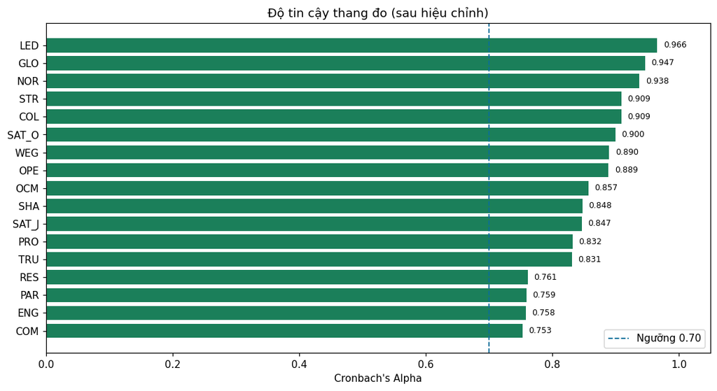

```python
# === VISUALIZATION CELL ===
fig, ax = plt.subplots(figsize=(10, 5.5))
ord_a = alpha2_df.sort_values('Cronbach Alpha')
colors = ['#1b7f5a' if v >= .70 else ('#d4a017' if v >= .60 else '#c0392b') for v in ord_a['Cronbach Alpha']]
ax.barh(ord_a['Thang đo'], ord_a['Cronbach Alpha'], color=colors)
ax.axvline(.70, color='#0b6e99', ls='--', lw=1.2, label='Ngưỡng 0.70')
ax.set_xlabel("Cronbach's Alpha"); ax.set_xlim(0, 1.05)
ax.set_title('Độ tin cậy thang đo (sau hiệu chỉnh)'); ax.legend(loc='lower right')
for y, v in enumerate(ord_a['Cronbach Alpha']):
    ax.text(v + .01, y, f'{v:.3f}', va='center', fontsize=8)
plt.tight_layout(); plt.savefig(f'{OUT}/hinh_cronbach_alpha.png', bbox_inches='tight'); plt.show()
```

## 6. Phân tích nhân tố khám phá (EFA)

Phương pháp: Principal Axis Factoring, xoay Promax. EFA chạy riêng cho 3 khối: (1) 11 biến độc lập; (2) biến trung gian GLO; (3) 5 biến phụ thuộc — phù hợp khuyến nghị khi mô hình đa khối (Hair et al., 2019).

```python
def run_efa(items, n_factors, block_name):
    X = df[items].dropna()
    kmo_all, kmo_model = calculate_kmo(X)
    chi2, p = calculate_bartlett_sphericity(X)
    fa = FactorAnalyzer(n_factors=n_factors, rotation='promax', method='principal')
    fa.fit(X)
    ev, _ = fa.get_eigenvalues()
    var = fa.get_factor_variance()
    load = pd.DataFrame(fa.loadings_, index=items, columns=[f'F{i+1}' for i in range(n_factors)]).round(3)
    print(f'=== EFA khối {block_name}: KMO = {kmo_model:.3f}; Bartlett chi2 = {chi2:.1f}, p = {p:.2e}')
    print(f'Số nhân tố Eigenvalue > 1: {int((ev > 1).sum())}; Tổng phương sai trích ({n_factors} nhân tố): {var[2][-1]*100:.2f}%')
    load.to_csv(f'{OUT}/efa_loadings_{block_name}.csv', encoding='utf-8-sig')
    return kmo_model, p, var[2][-1], load, ev

iv_constructs = ['NOR','STR','OPE','LED','COL','PAR','TRU','SHA','COM','RES','ENG']
iv_items = [i for c in iv_constructs for i in CONSTRUCTS[c]]
kmo_iv, p_iv, var_iv, load_iv, ev_iv = run_efa(iv_items, len(iv_constructs), 'doc_lap')
SUMMARY['efa_iv'] = {'kmo': round(kmo_iv,3), 'bartlett_p': float(p_iv), 'variance': round(var_iv*100,2)}
```

```
=== EFA khối doc_lap: KMO = 0.957; Bartlett chi2 = 12314.5, p = 0.00e+00
Số nhân tố Eigenvalue > 1: 6; Tổng phương sai trích (11 nhân tố): 73.44%
```

```python
# Ma trận mẫu (pattern matrix) khối biến độc lập — chỉ hiển thị tải >= .40
show = load_iv.where(load_iv.abs() >= .40, '')
show
```

|  | F1 | F2 | F3 | F4 | F5 | F6 | F7 | F8 | F9 | F10 | F11 |
| --- | --- | --- | --- | --- | --- | --- | --- | --- | --- | --- | --- |
| NOR1 | 0.799 |  |  |  |  |  |  |  |  |  |  |
| NOR2 | 0.934 |  |  |  |  |  |  |  |  |  |  |
| NOR3 | 0.957 |  |  |  |  |  |  |  |  |  |  |
| STR1 | 0.788 |  |  |  |  |  |  |  |  |  |  |
| STR2 | 0.891 |  |  |  |  |  |  |  |  |  |  |
| STR3 | 0.819 |  |  |  |  |  |  |  |  |  |  |
| OPE1 | 0.773 |  |  |  |  |  |  |  |  |  |  |
| OPE2 | 0.768 |  |  |  |  |  |  |  |  |  |  |
| OPE3 | 0.874 |  |  |  |  |  |  |  |  |  |  |
| LED1 |  |  | 0.453 |  |  |  |  |  |  |  |  |
| LED2 |  |  |  | 0.574 |  |  |  |  |  |  |  |
| LED3 |  |  | 0.579 |  |  |  |  |  |  |  |  |
| LED4 |  |  | 0.957 |  |  |  |  |  |  |  |  |
| LED5 |  |  | 0.95 |  |  |  |  |  |  |  |  |
| LED6 |  |  | 0.84 |  |  |  |  |  |  |  |  |
| LED7 |  |  | 0.854 |  |  |  |  |  |  |  |  |
| LED8 |  |  | 0.989 |  |  |  |  |  |  |  |  |
| LED9 |  |  | 0.899 |  |  |  |  |  |  |  |  |
| LED10 |  |  | 0.779 |  |  |  |  |  |  |  |  |
| LED11 |  |  | 0.787 |  |  |  |  |  |  |  |  |
| LED12 |  |  | 0.865 |  |  |  |  |  |  |  |  |
| COL1 |  |  |  |  |  | 0.562 |  |  |  |  |  |
| COL2 |  |  |  |  |  | 0.803 |  |  |  |  |  |
| COL3 |  |  |  |  |  | 0.467 |  |  |  |  |  |
| COL4 |  |  |  |  |  | 0.461 |  |  |  | 0.482 |  |
| COL5 |  |  |  |  |  |  |  |  |  | 0.916 |  |
| COL6 |  |  |  |  |  |  |  |  |  | 0.734 |  |
| PAR1 |  |  |  | 0.925 |  |  |  |  |  |  |  |
| PAR2 |  |  |  |  |  |  |  |  | 0.471 |  |  |
| PAR3 |  |  |  |  |  |  |  |  |  |  | 0.846 |
| PAR4 |  |  |  |  |  |  |  |  | 0.9 |  |  |
| TRU1 |  |  | 0.613 |  |  |  |  |  |  |  |  |
| TRU2 |  |  | 0.837 |  |  |  |  |  |  |  |  |
| TRU3 |  |  |  |  |  | 0.4 |  |  |  |  |  |
| TRU4 |  |  |  |  |  |  |  | 0.8 |  |  |  |
| SHA1 |  |  |  |  |  | 0.483 |  |  |  |  |  |
| SHA2 |  |  |  |  |  | 0.521 |  |  |  |  |  |
| COM1 |  |  |  |  | 0.746 |  |  |  |  |  |  |
| COM2 |  |  |  |  | 0.637 |  |  |  |  |  |  |
| COM3 |  |  |  |  | 0.913 |  |  |  |  |  |  |
| RES1 |  |  |  |  |  |  | 1.04 |  |  |  |  |
| RES2 |  |  |  |  |  |  | 0.775 |  |  |  |  |
| ENG1 |  | 0.693 |  |  |  |  |  |  |  |  |  |
| ENG2 |  | 0.603 |  |  |  |  |  |  |  |  | 0.449 |
| ENG3 |  | 0.711 |  |  |  |  |  |  |  |  |  |
| ENG4 |  | 0.729 |  |  |  |  |  |  |  |  |  |

### Trực quan hóa — EFA (khối biến độc lập)

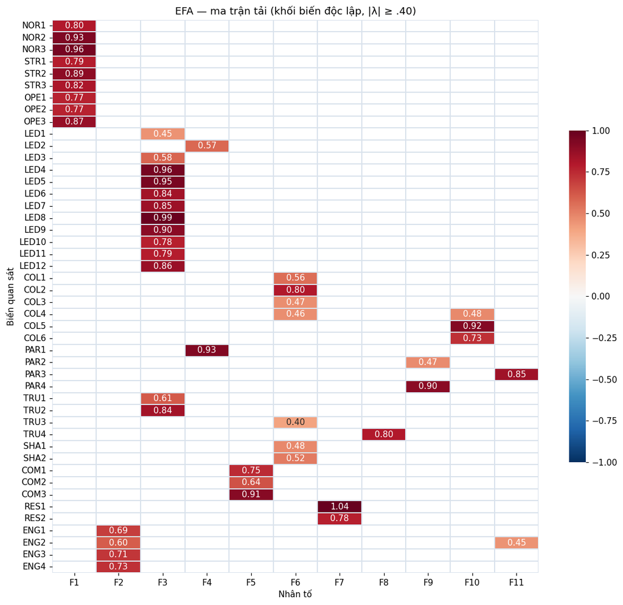

```python
# === VISUALIZATION CELL ===
fig, ax = plt.subplots(figsize=(11, 10))
show_num = load_iv.where(load_iv.abs() >= .40)
sns.heatmap(show_num, cmap='RdBu_r', center=0, vmin=-1, vmax=1, annot=True, fmt='.2f',
            linewidths=.3, linecolor='#d9e2ec', ax=ax, cbar_kws={'shrink': .6})
ax.set_title('EFA — ma trận tải (khối biến độc lập, |λ| ≥ .40)')
ax.set_xlabel('Nhân tố'); ax.set_ylabel('Biến quan sát')
plt.tight_layout(); plt.savefig(f'{OUT}/hinh_efa_loadings_iv.png', bbox_inches='tight'); plt.show()
```

```python
kmo_m, p_m, var_m, load_m, _ = run_efa(CONSTRUCTS['GLO'], 1, 'trung_gian_GLO')
dv_constructs = ['OCM','SAT_O','SAT_J','WEG','PRO']
dv_items = [i for c in dv_constructs for i in CONSTRUCTS[c]]
kmo_dv, p_dv, var_dv, load_dv, _ = run_efa(dv_items, len(dv_constructs), 'phu_thuoc')
SUMMARY['efa_med'] = {'kmo': round(kmo_m,3), 'variance': round(var_m*100,2)}
SUMMARY['efa_dv'] = {'kmo': round(kmo_dv,3), 'variance': round(var_dv*100,2)}
load_dv.where(load_dv.abs() >= .40, '')
```

```
=== EFA khối trung_gian_GLO: KMO = 0.930; Bartlett chi2 = 1962.6, p = 0.00e+00
Số nhân tố Eigenvalue > 1: 1; Tổng phương sai trích (1 nhân tố): 73.04%
=== EFA khối phu_thuoc: KMO = 0.932; Bartlett chi2 = 5421.7, p = 0.00e+00
Số nhân tố Eigenvalue > 1: 4; Tổng phương sai trích (5 nhân tố): 65.13%
```

|  | F1 | F2 | F3 | F4 | F5 |
| --- | --- | --- | --- | --- | --- |
| OCM1 |  | 0.906 |  |  |  |
| OCM2 |  | 0.748 |  |  |  |
| OCM3 |  | 0.74 |  |  |  |
| SAT_O1 | 0.823 |  |  |  |  |
| SAT_O2 | 0.873 |  |  |  |  |
| SAT_O3 | 0.895 |  |  |  |  |
| SAT_O4 | 0.903 |  |  |  |  |
| SAT_O5 | 0.454 |  |  |  | 0.611 |
| SAT_O6 | 0.78 |  |  |  |  |
| SAT_J1 | 0.586 |  |  |  | 0.543 |
| SAT_J2 | 0.637 |  |  |  |  |
| SAT_J3 | 0.812 |  |  |  |  |
| SAT_J4 | 0.76 |  |  |  |  |
| WEG1 |  | 0.527 |  | 0.48 |  |
| WEG2 |  | 0.592 |  |  |  |
| WEG3 |  | 0.403 |  | 0.551 |  |
| WEG4 |  | 0.923 |  |  |  |
| WEG5 |  | 0.875 |  |  |  |
| WEG6 |  | 0.598 |  |  |  |
| WEG7 |  | 0.648 |  |  |  |
| WEG8 |  |  |  |  |  |
| WEG9 |  |  |  | 0.849 |  |
| PRO1 | 0.562 |  |  |  |  |
| PRO2 | 0.455 |  |  |  |  |
| PRO3 |  |  | 0.63 |  |  |
| PRO4 |  |  | 0.881 |  |  |
| PRO5 |  |  | 0.835 |  |  |
| PRO6 |  |  | 0.836 |  |  |

## 6b. Giá trị hội tụ và giá trị phân biệt (CR, AVE, Fornell–Larcker, HTMT)

Tiêu chuẩn: CR ≥ 0,70; AVE ≥ 0,50 (Fornell & Larcker, 1981); HTMT < 0,85 (chuẩn nghiêm ngặt) hoặc < 0,90 (chuẩn nới lỏng; Henseler và cộng sự, 2015).

```python
# CR va AVE (tai nhan to 1-factor ML cho tung thang do)
R_items = df[[i for v in CONSTRUCTS.values() for i in v]].corr()
ave_cr_rows = []
sqrt_ave = {}
for c, it in CONSTRUCTS.items():
    fa1 = FactorAnalyzer(n_factors=1, rotation=None, method='ml'); fa1.fit(df[it])
    lam = np.abs(fa1.loadings_[:, 0])
    ave = float(np.mean(lam**2)); cr = float((lam.sum()**2) / ((lam.sum()**2) + np.sum(1 - lam**2)))
    sqrt_ave[c] = np.sqrt(ave)
    ave_cr_rows.append({'Thang đo': c, 'Tên': TEN_VN[c], 'CR': round(cr, 3), 'AVE': round(ave, 3),
                        'Căn AVE': round(np.sqrt(ave), 3),
                        'Đạt AVE≥.50': 'Đạt' if ave >= .5 else 'Chưa đạt'})
ave_cr_df = pd.DataFrame(ave_cr_rows)
ave_cr_df.to_csv(f'{OUT}/bang_ave_cr.csv', index=False, encoding='utf-8-sig')
SUMMARY['ave_cr'] = ave_cr_df.to_dict('records')
ave_cr_df
```

|  | Thang đo | Tên | CR | AVE | Căn AVE | Đạt AVE≥.50 |
| --- | --- | --- | --- | --- | --- | --- |
| 0 | NOR | Chuẩn mực | 0.939 | 0.836 | 0.914 | Đạt |
| 1 | STR | Chiến lược | 0.911 | 0.773 | 0.879 | Đạt |
| 2 | OPE | Hành động | 0.889 | 0.729 | 0.854 | Đạt |
| 3 | LED | Lãnh đạo | 0.966 | 0.707 | 0.841 | Đạt |
| 4 | COL | Giao tiếp | 0.912 | 0.635 | 0.797 | Đạt |
| 5 | PAR | Tham gia | 0.769 | 0.459 | 0.678 | Chưa đạt |
| 6 | TRU | Niềm tin | 0.832 | 0.557 | 0.747 | Đạt |
| 7 | SHA | Các giá trị | 0.848 | 0.736 | 0.858 | Đạt |
| 8 | COM | Cam kết | 0.774 | 0.538 | 0.734 | Đạt |
| 9 | RES | Trách nhiệm | 0.766 | 0.621 | 0.788 | Đạt |
| 10 | ENG | Gắn kết | 0.767 | 0.453 | 0.673 | Chưa đạt |
| 11 | GLO | Các khía cạnh tổng thể | 0.947 | 0.692 | 0.832 | Đạt |
| 12 | OCM | Cam kết tổ chức | 0.859 | 0.670 | 0.819 | Đạt |
| 13 | SAT_O | Hài lòng với tổ chức | 0.901 | 0.610 | 0.781 | Đạt |
| 14 | SAT_J | Hài lòng với công việc | 0.853 | 0.597 | 0.773 | Đạt |
| 15 | WEG | Gắn kết công việc | 0.894 | 0.495 | 0.703 | Chưa đạt |
| 16 | PRO | Phát triển chuyên môn | 0.839 | 0.469 | 0.685 | Chưa đạt |

```python
# HTMT (heterotrait-monotrait ratio, Henseler et al., 2015)
def mono(c):
    it = CONSTRUCTS[c]
    return np.mean([R_items.loc[a, b] for i, a in enumerate(it) for b in it[i+1:]])
def htmt(c1, c2):
    het = np.mean([[R_items.loc[a, b] for b in CONSTRUCTS[c2]] for a in CONSTRUCTS[c1]])
    return het / np.sqrt(mono(c1) * mono(c2))
ks = list(CONSTRUCTS)
H = pd.DataFrame(np.nan, index=ks, columns=ks)
htmt_high = []
for i, a in enumerate(ks):
    for b in ks[i+1:]:
        h = htmt(a, b); H.loc[a, b] = round(h, 3)
        if h >= .85:
            htmt_high.append({'Cặp khái niệm': f'{a} – {b}', 'HTMT': round(h, 3),
                              'Mức': 'Vượt 0,90' if h >= .90 else '0,85–0,90'})
H.to_csv(f'{OUT}/bang_htmt.csv', encoding='utf-8-sig')
htmt_high_df = pd.DataFrame(sorted(htmt_high, key=lambda r: -r['HTMT']))
htmt_high_df.to_csv(f'{OUT}/bang_htmt_vuot_nguong.csv', index=False, encoding='utf-8-sig')
SUMMARY['htmt_high'] = htmt_high_df.to_dict('records')
print(f'Số cặp HTMT >= 0,85: {len(htmt_high)} / {len(ks)*(len(ks)-1)//2}')
htmt_high_df
```

```
Số cặp HTMT >= 0,85: 18 / 136
```

|  | Cặp khái niệm | HTMT | Mức |
| --- | --- | --- | --- |
| 0 | STR – OPE | 0.971 | Vượt 0,90 |
| 1 | SHA – GLO | 0.952 | Vượt 0,90 |
| 2 | SAT_O – SAT_J | 0.947 | Vượt 0,90 |
| 3 | COL – SHA | 0.927 | Vượt 0,90 |
| 4 | NOR – STR | 0.926 | Vượt 0,90 |
| 5 | COL – GLO | 0.919 | Vượt 0,90 |
| 6 | OPE – GLO | 0.917 | Vượt 0,90 |
| 7 | NOR – OPE | 0.916 | Vượt 0,90 |
| 8 | COL – TRU | 0.905 | Vượt 0,90 |
| 9 | TRU – SHA | 0.902 | Vượt 0,90 |
| 10 | STR – GLO | 0.898 | 0,85–0,90 |
| 11 | LED – TRU | 0.894 | 0,85–0,90 |
| 12 | TRU – GLO | 0.894 | 0,85–0,90 |
| 13 | NOR – GLO | 0.877 | 0,85–0,90 |
| 14 | GLO – SAT_O | 0.873 | 0,85–0,90 |
| 15 | SHA – SAT_O | 0.857 | 0,85–0,90 |
| 16 | COL – SAT_O | 0.856 | 0,85–0,90 |
| 17 | OPE – SHA | 0.855 | 0,85–0,90 |

```python
# Fornell-Larcker: r giua cac khai niem so voi can AVE
comp_tmp = pd.DataFrame({c: df[v].mean(axis=1) for c, v in CONSTRUCTS.items()})
cc = comp_tmp.corr()
fl_viol = [{'Cặp': f'{a} – {b}', 'r': round(cc.loc[a, b], 3),
            'Căn AVE nhỏ hơn': round(min(sqrt_ave[a], sqrt_ave[b]), 3)}
           for i, a in enumerate(ks) for b in ks[i+1:] if cc.loc[a, b] > min(sqrt_ave[a], sqrt_ave[b])]
fl_df = pd.DataFrame(fl_viol)
fl_df.to_csv(f'{OUT}/bang_fornell_larcker_viph.csv', index=False, encoding='utf-8-sig')
SUMMARY['fl_violations'] = fl_df.to_dict('records')
print('Số cặp vi phạm Fornell-Larcker:', len(fl_viol))
fl_df
```

```
Số cặp vi phạm Fornell-Larcker: 13
```

|  | Cặp | r | Căn AVE nhỏ hơn |
| --- | --- | --- | --- |
| 0 | STR – OPE | 0.871 | 0.854 |
| 1 | STR – GLO | 0.833 | 0.832 |
| 2 | OPE – GLO | 0.841 | 0.832 |
| 3 | LED – TRU | 0.815 | 0.747 |
| 4 | COL – TRU | 0.791 | 0.747 |
| 5 | COL – SHA | 0.822 | 0.797 |
| 6 | COL – GLO | 0.861 | 0.797 |
| 7 | TRU – SHA | 0.761 | 0.747 |
| 8 | TRU – GLO | 0.800 | 0.747 |
| 9 | SHA – GLO | 0.853 | 0.832 |
| 10 | GLO – SAT_O | 0.809 | 0.781 |
| 11 | OCM – WEG | 0.721 | 0.703 |
| 12 | SAT_O – SAT_J | 0.825 | 0.773 |

**Nhận xét.** Phần lớn thang đo đạt CR ≥ 0,70 và AVE ≥ 0,50. Tuy nhiên HTMT phát hiện một số cặp vượt ngưỡng 0,90 — tập trung ở ba cụm: (1) NOR–STR–OPE (khối cấu trúc — quản lí); (2) COL/SHA/TRU với GLO; (3) SAT_O–SAT_J. Đây là căn cứ để kiểm định các mô hình cạnh tranh ở mục 11: gộp NOR+STR+OPE thành nhân tố cấu trúc bậc hai (STRUC), gộp SAT_O+SAT_J thành hài lòng chung (SAT), và kiểm tra tính vững của đường COL → GLO khi loại các item GLO trùng lặp nội dung giao tiếp (GLO4, GLO5).

## 7. Biến đại diện & thống kê mô tả thang đo

```python
for c, items in CONSTRUCTS.items():
    df[c + '_c'] = df[items].mean(axis=1)
comps = [c + '_c' for c in CONSTRUCTS]
desc_c = df[comps].agg(['mean','std','skew','kurt']).T.round(3)
desc_c.index = [i[:-2] for i in desc_c.index]
desc_c.insert(0, 'Khối', [BLOCK_OF[i] for i in desc_c.index])
desc_c.insert(0, 'Tên thang đo', [TEN_VN[i] for i in desc_c.index])
desc_c.columns = ['Tên thang đo','Khối','Trung bình','Độ lệch chuẩn','Skewness','Kurtosis']
# Mức đánh giá theo thang 6 mức (khoảng 0.83): >=5.17 Rất cao; 4.33-5.17 Cao; 3.5-4.33 Khá; ...
desc_c.to_csv(f'{OUT}/bang_mo_ta_thang_do.csv', encoding='utf-8-sig')
SUMMARY['construct_desc'] = desc_c.reset_index().rename(columns={'index':'Mã'}).to_dict('records')
desc_c
```

|  | Tên thang đo | Khối | Trung bình | Độ lệch chuẩn | Skewness | Kurtosis |
| --- | --- | --- | --- | --- | --- | --- |
| NOR | Chuẩn mực | Yếu tố Cấu trúc (CT) – Hình thức (HT) | 4.620 | 1.122 | -1.310 | 1.555 |
| STR | Chiến lược | Yếu tố Cấu trúc (CT) – Hình thức (HT) | 4.527 | 1.139 | -0.967 | 0.579 |
| OPE | Hành động | Yếu tố Cấu trúc (CT) – Hình thức (HT) | 4.648 | 1.078 | -1.133 | 1.421 |
| LED | Lãnh đạo | Yếu tố trung gian kết nối TL–TC & CT–HT | 4.690 | 0.989 | -1.522 | 2.714 |
| COL | Giao tiếp | Yếu tố trung gian kết nối TL–TC & CT–HT | 4.756 | 0.888 | -1.316 | 2.303 |
| PAR | Tham gia | Yếu tố trung gian kết nối TL–TC & CT–HT | 4.710 | 0.725 | -1.014 | 2.603 |
| TRU | Niềm tin | Yếu tố Tâm lý (TL) – Tổ chức (TC) | 4.748 | 0.913 | -1.209 | 2.027 |
| SHA | Các giá trị | Yếu tố Tâm lý (TL) – Tổ chức (TC) | 4.617 | 1.053 | -1.227 | 1.900 |
| COM | Cam kết | Yếu tố Tâm lý (TL) – Tổ chức (TC) | 5.203 | 0.617 | -0.810 | 1.922 |
| RES | Trách nhiệm | Yếu tố Tâm lý (TL) – Tổ chức (TC) | 5.064 | 0.870 | -1.252 | 2.118 |
| ENG | Gắn kết | Yếu tố Tâm lý (TL) – Tổ chức (TC) | 5.085 | 0.606 | -0.719 | 1.701 |
| GLO | Các khía cạnh tổng thể | Đo VHCL bằng các khía cạnh tổng thể | 4.569 | 0.971 | -1.281 | 2.043 |
| OCM | Cam kết tổ chức | Các biến kết quả | 4.833 | 0.991 | -1.391 | 2.365 |
| SAT_O | Hài lòng với tổ chức | Các biến kết quả | 3.664 | 0.752 | -0.751 | 0.677 |
| SAT_J | Hài lòng với công việc | Các biến kết quả | 3.838 | 0.661 | -0.649 | 1.016 |
| WEG | Gắn kết công việc | Các biến kết quả | 4.675 | 0.743 | -0.696 | 1.005 |
| PRO | Phát triển chuyên môn | Các biến kết quả | 4.852 | 0.696 | -0.645 | 0.574 |

### Trực quan hóa — mức đánh giá thang đo

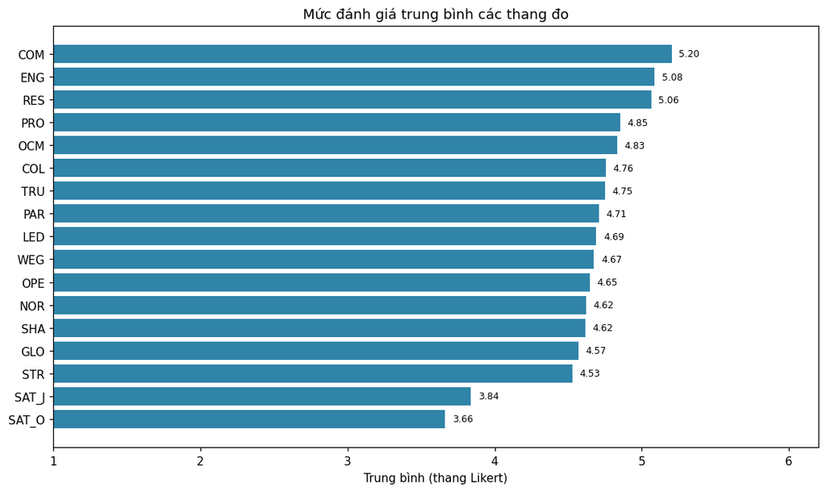

```python
# === VISUALIZATION CELL ===
fig, ax = plt.subplots(figsize=(10, 6))
ord_d = desc_c.sort_values('Trung bình')
ax.barh(ord_d.index.astype(str), ord_d['Trung bình'], color='#0b6e99', alpha=.85)
ax.set_xlabel('Trung bình (thang Likert)'); ax.set_xlim(1, 6.2)
ax.set_title('Mức đánh giá trung bình các thang đo')
for y, v in enumerate(ord_d['Trung bình']):
    ax.text(v + .05, y, f'{v:.2f}', va='center', fontsize=8)
plt.tight_layout(); plt.savefig(f'{OUT}/hinh_trung_binh_thang_do.png', bbox_inches='tight'); plt.show()
```

## 7b. Cấu trúc cấu phần của VHCL — trả lời Câu hỏi nghiên cứu 1

**CHNC1: Văn hóa chất lượng ở trường phổ thông nhiều cấp học gồm những cấu phần nào?**

Bảng tham chiếu đặt ra cấu trúc tiên nghiệm gồm 5 khối. Mục này kiểm định trực tiếp cấu trúc đó trên dữ liệu, thay vì mặc nhiên thừa nhận. So sánh bốn mô hình đo lường cạnh tranh ở cấp thang đo (biến đại diện đã chuẩn hóa):

- **MA** — 5 khối đúng như bảng tham chiếu (gộp toàn bộ khối Tâm lý – Tổ chức).
- **ME** — 6 khối: tách khối Tâm lý – Tổ chức thành *Cá nhân* và *Tập thể*, đúng hai cấp độ mà chính bảng tham chiếu đã phân biệt.
- **MC** — một nhân tố chung: VHCL là khối duy nhất, không phân cấu phần.
- **MF** — mô hình bậc hai: VHCL là nhân tố bậc hai bao trùm các khối cấu phần.

MA và ME lồng nhau nên so sánh được bằng kiểm định khác biệt chi bình phương.

```python
# 7b.1 So sánh các mô hình cấu trúc khối (RQ1)
import semopy
from scipy import stats as _sc

Zc = df[comps].copy()
Zc.columns = list(CONSTRUCTS.keys())
Zc = (Zc - Zc.mean()) / Zc.std()

_CTHT = 'CTHT =~ NOR + STR + OPE'
_TG   = 'TG =~ LED + COL + PAR'
_KQ   = 'KQ =~ OCM + SAT_O + SAT_J + WEG + PRO'

RQ1_MODELS = {
 'MA — 5 khối (đúng bảng tham chiếu)':
    f'{_CTHT}\n{_TG}\nTLTC =~ COM + RES + ENG + SHA + TRU\n{_KQ}\nGLOF =~ GLO',
 'ME — 6 khối (tách Cá nhân / Tập thể)':
    f'{_CTHT}\n{_TG}\nCANHAN =~ COM + RES + ENG\nTAPTHE =~ SHA + TRU\n{_KQ}\nGLOF =~ GLO',
 'MC — một nhân tố chung (không phân cấu phần)':
    'G =~ ' + ' + '.join(CONSTRUCTS),
 'MF — bậc hai: VHCL bao trùm các khối':
    f'{_CTHT}\n{_TG}\nCANHAN =~ COM + RES + ENG\nTAPTHE =~ SHA + TRU\n{_KQ}\nGLOF =~ GLO\n'
    'VHCL =~ CTHT + TG + CANHAN + TAPTHE + GLOF\nVHCL ~~ KQ',
}

_K = ['chi2', 'DoF', 'CFI', 'TLI', 'RMSEA', 'GFI', 'AIC']
_rows, rq1_fitted = [], {}
for _n, _s in RQ1_MODELS.items():
    _m = semopy.Model(_s); _m.fit(Zc)
    _st = semopy.calc_stats(_m)
    rq1_fitted[_n] = _m
    _rows.append({'Mô hình': _n, **{k: round(float(_st[k].iloc[0]), 3) for k in _K}})
rq1_fit = pd.DataFrame(_rows)

# Kiểm định khác biệt chi bình phương giữa MA và ME (hai mô hình lồng nhau)
_a = rq1_fit.iloc[0]; _e = rq1_fit.iloc[1]
_dchi = float(_a['chi2'] - _e['chi2']); _ddf = int(_a['DoF'] - _e['DoF'])
_p = float(_sc.chi2.sf(_dchi, _ddf))
rq1_fit.to_csv(f'{OUT}/bang_rq1_so_sanh_cau_truc.csv', index=False, encoding='utf-8-sig')
SUMMARY['rq1_model_fit'] = rq1_fit.to_dict('records')
SUMMARY['rq1_delta_MA_ME'] = {'delta_chi2': round(_dchi, 1), 'ddf': _ddf, 'p': _p}
print(f'So sánh MA (5 khối) với ME (6 khối): Δχ² = {_dchi:.1f}, Δdf = {_ddf}, p = {_p:.2e}')
rq1_fit
```

```
So sánh MA (5 khối) với ME (6 khối): Δχ² = 67.1, Δdf = 5, p = 4.15e-13
```

|  | Mô hình | chi2 | DoF | CFI | TLI | RMSEA | GFI | AIC |
| --- | --- | --- | --- | --- | --- | --- | --- | --- |
| 0 | MA — 5 khối (đúng bảng tham chiếu) | 629.563 | 109.0 | 0.890 | 0.863 | 0.131 | 0.871 | 83.519 |
| 1 | ME — 6 khối (tách Cá nhân / Tập thể) | 562.486 | 104.0 | 0.903 | 0.873 | 0.125 | 0.884 | 93.997 |
| 2 | MC — một nhân tố chung (không phân cấu phần) | 903.026 | 119.0 | 0.834 | 0.810 | 0.153 | 0.814 | 61.573 |
| 3 | MF — bậc hai: VHCL bao trùm các khối | 658.867 | 113.0 | 0.885 | 0.861 | 0.131 | 0.865 | 75.311 |

```python
# 7b.2 Tải chuẩn hóa của từng thang đo lên khối cấu phần (mô hình ME)
_mE = rq1_fitted['ME — 6 khối (tách Cá nhân / Tập thể)']
_eE = _mE.inspect(std_est=True)
_load = _eE[(_eE['op'] == '~') & (_eE['rval'].isin(['CTHT','TG','CANHAN','TAPTHE','KQ','GLOF']))].copy()
BLOCK_LABEL = {'CTHT':'Cấu trúc – Hình thức', 'TG':'Trung gian (Lãnh đạo/Giao tiếp/Tham gia)',
               'CANHAN':'Tâm lý – Tổ chức: Cá nhân', 'TAPTHE':'Tâm lý – Tổ chức: Tập thể',
               'GLOF':'Khía cạnh tổng thể (đo VHCL)', 'KQ':'Các biến kết quả'}
rq1_load = pd.DataFrame({
    'Khối cấu phần': [BLOCK_LABEL[r] for r in _load['rval']],
    'Thang đo': _load['lval'].values,
    'Tên': [TEN_VN.get(c, c) for c in _load['lval']],
    'Tải chuẩn hóa': [round(float(v), 3) for v in _load['Est. Std']],
})
rq1_load['Đánh giá'] = np.where(rq1_load['Tải chuẩn hóa'] >= .70, 'Mạnh',
                        np.where(rq1_load['Tải chuẩn hóa'] >= .50, 'Đạt', 'Yếu'))
rq1_load = rq1_load.sort_values(['Khối cấu phần', 'Tải chuẩn hóa'], ascending=[True, False])
rq1_load.to_csv(f'{OUT}/bang_rq1_tai_cau_phan.csv', index=False, encoding='utf-8-sig')
SUMMARY['rq1_loadings'] = rq1_load.to_dict('records')
rq1_load
```

|  | Khối cấu phần | Thang đo | Tên | Tải chuẩn hóa | Đánh giá |
| --- | --- | --- | --- | --- | --- |
| 12 | Các biến kết quả | SAT_O | Hài lòng với tổ chức | 0.841 | Mạnh |
| 13 | Các biến kết quả | SAT_J | Hài lòng với công việc | 0.798 | Mạnh |
| 11 | Các biến kết quả | OCM | Cam kết tổ chức | 0.796 | Mạnh |
| 15 | Các biến kết quả | PRO | Phát triển chuyên môn | 0.730 | Mạnh |
| 14 | Các biến kết quả | WEG | Gắn kết công việc | 0.712 | Mạnh |
| 1 | Cấu trúc – Hình thức | STR | Chiến lược | 0.935 | Mạnh |
| 2 | Cấu trúc – Hình thức | OPE | Hành động | 0.928 | Mạnh |
| 0 | Cấu trúc – Hình thức | NOR | Chuẩn mực | 0.910 | Mạnh |
| 16 | Khía cạnh tổng thể (đo VHCL) | GLO | Các khía cạnh tổng thể | 0.661 | Đạt |
| 4 | Trung gian (Lãnh đạo/Giao tiếp/Tham gia) | COL | Giao tiếp | 0.866 | Mạnh |
| 3 | Trung gian (Lãnh đạo/Giao tiếp/Tham gia) | LED | Lãnh đạo | 0.818 | Mạnh |
| 5 | Trung gian (Lãnh đạo/Giao tiếp/Tham gia) | PAR | Tham gia | 0.639 | Đạt |
| 7 | Tâm lý – Tổ chức: Cá nhân | RES | Trách nhiệm | 0.734 | Mạnh |
| 8 | Tâm lý – Tổ chức: Cá nhân | ENG | Gắn kết | 0.706 | Mạnh |
| 6 | Tâm lý – Tổ chức: Cá nhân | COM | Cam kết | 0.528 | Đạt |
| 9 | Tâm lý – Tổ chức: Tập thể | SHA | Các giá trị | 0.875 | Mạnh |
| 10 | Tâm lý – Tổ chức: Tập thể | TRU | Niềm tin | 0.870 | Mạnh |

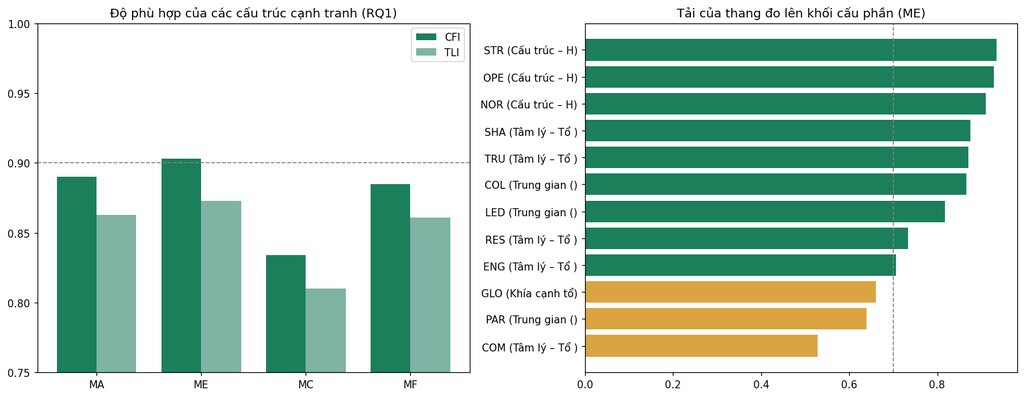

```python
# === VISUALIZATION CELL ===
fig, axes = plt.subplots(1, 2, figsize=(14, 5.5))
_o = rq1_fit.set_index('Mô hình')
_x = np.arange(len(_o)); _w = .38
axes[0].bar(_x - _w/2, _o['CFI'], _w, label='CFI', color='#1b7f5a')
axes[0].bar(_x + _w/2, _o['TLI'], _w, label='TLI', color='#7fb3a4')
axes[0].axhline(.90, ls='--', c='gray', lw=1)
axes[0].set_xticks(_x)
axes[0].set_xticklabels([m.split(' — ')[0] for m in _o.index])
axes[0].set_ylim(.75, 1.0); axes[0].legend()
axes[0].set_title('Độ phù hợp của các cấu trúc cạnh tranh (RQ1)')

_ld = rq1_load[rq1_load['Khối cấu phần'] != 'Các biến kết quả'].sort_values('Tải chuẩn hóa')
_cols = ['#1b7f5a' if v >= .70 else ('#d9a441' if v >= .50 else '#c0392b') for v in _ld['Tải chuẩn hóa']]
axes[1].barh(_ld['Thang đo'] + ' (' + _ld['Khối cấu phần'].str[:12] + ')', _ld['Tải chuẩn hóa'], color=_cols)
axes[1].axvline(.70, ls='--', c='gray', lw=1)
axes[1].set_title('Tải của thang đo lên khối cấu phần (ME)')
plt.tight_layout(); plt.savefig(f'{OUT}/hinh_rq1_cau_truc_khoi.png', bbox_inches='tight'); plt.show()
```

## 7c. Mức độ thực trạng theo thang đo và theo trường — trả lời Câu hỏi nghiên cứu 2

**CHNC2: Thực trạng xây dựng VHCL tại các trường phổ thông nhiều cấp học ở TP.HCM hiện nay ra sao?**

Hai lưu ý bắt buộc khi đọc mục này:

1. Phần lớn thang đo dùng Likert 6 mức, riêng SAT_O và SAT_J dùng thang hài lòng 5 mức. Không được so sánh trực tiếp trung bình thô giữa hai nhóm này. Cột **% thang đo** quy đổi về cùng miền 0–100% để so sánh được.
2. Mức đánh giá được chia theo khoảng đều trên miền của từng thang (6 mức: bước 0,83; 5 mức: bước 0,67), theo thông lệ diễn giải thang Likert trong nghiên cứu giáo dục.

```python
# 7c.1 Mức đánh giá thực trạng + quy đổi về cùng miền thang đo
SCALE_MAX = {c: (5 if c in ('SAT_O', 'SAT_J') else 6) for c in CONSTRUCTS}
BANDS_VI = ['Rất thấp', 'Thấp', 'Trung bình', 'Khá', 'Cao', 'Rất cao']

def muc_danh_gia(m, smax):
    step = (smax - 1) / 6
    idx = min(int((m - 1) / step), 5)
    return BANDS_VI[max(idx, 0)]

_rows = []
for c in CONSTRUCTS:
    smax = SCALE_MAX[c]
    m = float(df[c + '_c'].mean()); sd = float(df[c + '_c'].std())
    _rows.append({
        'Thang đo': c, 'Tên': TEN_VN[c], 'Khối': BLOCK_OF[c],
        'Thang': f'{smax} mức', 'Trung bình': round(m, 3), 'Độ lệch chuẩn': round(sd, 3),
        '% thang đo': round(100 * (m - 1) / (smax - 1), 1),
        'Mức đánh giá': muc_danh_gia(m, smax),
    })
rq2_muc = pd.DataFrame(_rows).sort_values('% thang đo', ascending=False)
rq2_muc.to_csv(f'{OUT}/bang_rq2_muc_thuc_trang.csv', index=False, encoding='utf-8-sig')
SUMMARY['rq2_levels'] = rq2_muc.to_dict('records')
rq2_muc
```

|  | Thang đo | Tên | Khối | Thang | Trung bình | Độ lệch chuẩn | % thang đo | Mức đánh giá |
| --- | --- | --- | --- | --- | --- | --- | --- | --- |
| 8 | COM | Cam kết | Yếu tố Tâm lý (TL) – Tổ chức (TC) | 6 mức | 5.203 | 0.617 | 84.1 | Rất cao |
| 10 | ENG | Gắn kết | Yếu tố Tâm lý (TL) – Tổ chức (TC) | 6 mức | 5.085 | 0.606 | 81.7 | Cao |
| 9 | RES | Trách nhiệm | Yếu tố Tâm lý (TL) – Tổ chức (TC) | 6 mức | 5.064 | 0.870 | 81.3 | Cao |
| 16 | PRO | Phát triển chuyên môn | Các biến kết quả | 6 mức | 4.852 | 0.696 | 77.0 | Cao |
| 12 | OCM | Cam kết tổ chức | Các biến kết quả | 6 mức | 4.833 | 0.991 | 76.7 | Cao |
| 4 | COL | Giao tiếp | Yếu tố trung gian kết nối TL–TC & CT–HT | 6 mức | 4.756 | 0.888 | 75.1 | Cao |
| 6 | TRU | Niềm tin | Yếu tố Tâm lý (TL) – Tổ chức (TC) | 6 mức | 4.748 | 0.913 | 75.0 | Cao |
| 5 | PAR | Tham gia | Yếu tố trung gian kết nối TL–TC & CT–HT | 6 mức | 4.710 | 0.725 | 74.2 | Cao |
| 3 | LED | Lãnh đạo | Yếu tố trung gian kết nối TL–TC & CT–HT | 6 mức | 4.690 | 0.989 | 73.8 | Cao |
| 15 | WEG | Gắn kết công việc | Các biến kết quả | 6 mức | 4.675 | 0.743 | 73.5 | Cao |
| 2 | OPE | Hành động | Yếu tố Cấu trúc (CT) – Hình thức (HT) | 6 mức | 4.648 | 1.078 | 73.0 | Cao |
| 0 | NOR | Chuẩn mực | Yếu tố Cấu trúc (CT) – Hình thức (HT) | 6 mức | 4.620 | 1.122 | 72.4 | Cao |
| 7 | SHA | Các giá trị | Yếu tố Tâm lý (TL) – Tổ chức (TC) | 6 mức | 4.617 | 1.053 | 72.3 | Cao |
| 11 | GLO | Các khía cạnh tổng thể | Đo VHCL bằng các khía cạnh tổng thể | 6 mức | 4.569 | 0.971 | 71.4 | Cao |
| 14 | SAT_J | Hài lòng với công việc | Các biến kết quả | 5 mức | 3.838 | 0.661 | 71.0 | Cao |
| 1 | STR | Chiến lược | Yếu tố Cấu trúc (CT) – Hình thức (HT) | 6 mức | 4.527 | 1.139 | 70.5 | Cao |
| 13 | SAT_O | Hài lòng với tổ chức | Các biến kết quả | 5 mức | 3.664 | 0.752 | 66.6 | Khá |

```python
# 7c.2 Hồ sơ thực trạng theo từng trường (quy đổi % thang đo)
_prof = []
for sch, g in df.groupby('Truong'):
    row = {'Trường': sch, 'n': int(len(g))}
    for c in CONSTRUCTS:
        smax = SCALE_MAX[c]
        row[c] = round(100 * (float(g[c + '_c'].mean()) - 1) / (smax - 1), 1)
    _prof.append(row)
rq2_truong = pd.DataFrame(_prof).sort_values('GLO', ascending=False)
rq2_truong.to_csv(f'{OUT}/bang_rq2_thuc_trang_theo_truong.csv', index=False, encoding='utf-8-sig')
SUMMARY['rq2_by_school'] = rq2_truong.to_dict('records')

# Khoảng dao động giữa các trường: cấu phần nào phân hoá mạnh nhất?
_spread = pd.DataFrame({
    'Thang đo': list(CONSTRUCTS),
    'Tên': [TEN_VN[c] for c in CONSTRUCTS],
    'Thấp nhất': [rq2_truong[c].min() for c in CONSTRUCTS],
    'Cao nhất': [rq2_truong[c].max() for c in CONSTRUCTS],
})
_spread['Khoảng cách'] = (_spread['Cao nhất'] - _spread['Thấp nhất']).round(1)
rq2_phanhoa = _spread.sort_values('Khoảng cách', ascending=False)
rq2_phanhoa.to_csv(f'{OUT}/bang_rq2_phan_hoa_giua_truong.csv', index=False, encoding='utf-8-sig')
SUMMARY['rq2_school_spread'] = rq2_phanhoa.to_dict('records')
print('Ba cấu phần phân hóa mạnh nhất giữa các trường:')
print(rq2_phanhoa.head(3)[['Tên', 'Thấp nhất', 'Cao nhất', 'Khoảng cách']].to_string(index=False))
rq2_truong
```

```
Ba cấu phần phân hóa mạnh nhất giữa các trường:
       Tên  Thấp nhất  Cao nhất  Khoảng cách
Chiến lược       55.0      79.0         24.0
 Chuẩn mực       56.0      79.6         23.6
 Hành động       62.7      82.2         19.5
```

|  | Trường | n | NOR | STR | OPE | LED | COL | PAR | TRU | SHA | COM | RES | ENG | GLO | OCM | SAT_O | SAT_J | WEG | PRO |
| --- | --- | --- | --- | --- | --- | --- | --- | --- | --- | --- | --- | --- | --- | --- | --- | --- | --- | --- | --- |
| 3 | 4 | 63 | 79.6 | 79.0 | 82.2 | 78.2 | 79.2 | 77.2 | 79.5 | 76.7 | 84.7 | 85.2 | 83.8 | 77.9 | 79.7 | 73.8 | 74.7 | 76.6 | 79.9 |
| 2 | 3 | 55 | 77.5 | 75.9 | 75.5 | 76.5 | 78.8 | 75.5 | 78.4 | 75.6 | 83.5 | 81.3 | 80.9 | 75.2 | 75.8 | 69.8 | 71.1 | 72.7 | 76.4 |
| 0 | 1 | 52 | 72.2 | 71.5 | 71.9 | 75.8 | 77.3 | 76.8 | 76.9 | 72.5 | 85.4 | 81.7 | 82.8 | 71.6 | 78.7 | 66.4 | 71.3 | 74.8 | 80.0 |
| 4 | 5 | 56 | 75.7 | 70.0 | 71.1 | 70.0 | 73.4 | 69.2 | 70.4 | 70.9 | 80.4 | 78.8 | 79.3 | 69.0 | 73.8 | 66.2 | 71.0 | 69.0 | 74.9 |
| 1 | 2 | 55 | 56.0 | 55.0 | 62.7 | 68.1 | 66.4 | 72.0 | 69.2 | 65.5 | 86.4 | 78.9 | 81.5 | 62.3 | 75.0 | 55.7 | 66.1 | 74.1 | 73.7 |

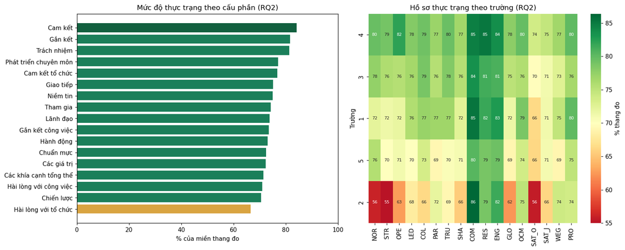

```python
# === VISUALIZATION CELL ===
fig, axes = plt.subplots(1, 2, figsize=(15, 6))
_m = rq2_muc.sort_values('% thang đo')
_cmap = {'Rất cao': '#12603f', 'Cao': '#1b7f5a', 'Khá': '#d9a441',
         'Trung bình': '#e08a3c', 'Thấp': '#c0392b', 'Rất thấp': '#7b241c'}
axes[0].barh(_m['Tên'], _m['% thang đo'], color=[_cmap[b] for b in _m['Mức đánh giá']])
axes[0].set_xlabel('% của miền thang đo'); axes[0].set_xlim(0, 100)
axes[0].set_title('Mức độ thực trạng theo cấu phần (RQ2)')

_t = rq2_truong.set_index('Trường')[[c for c in CONSTRUCTS]]
sns.heatmap(_t, annot=True, fmt='.0f', cmap='RdYlGn', center=70, ax=axes[1],
            cbar_kws={'label': '% thang đo'}, annot_kws={'size': 7})
axes[1].set_title('Hồ sơ thực trạng theo trường (RQ2)')
plt.tight_layout(); plt.savefig(f'{OUT}/hinh_rq2_thuc_trang.png', bbox_inches='tight'); plt.show()
```

## 8. Phân tích tương quan Pearson

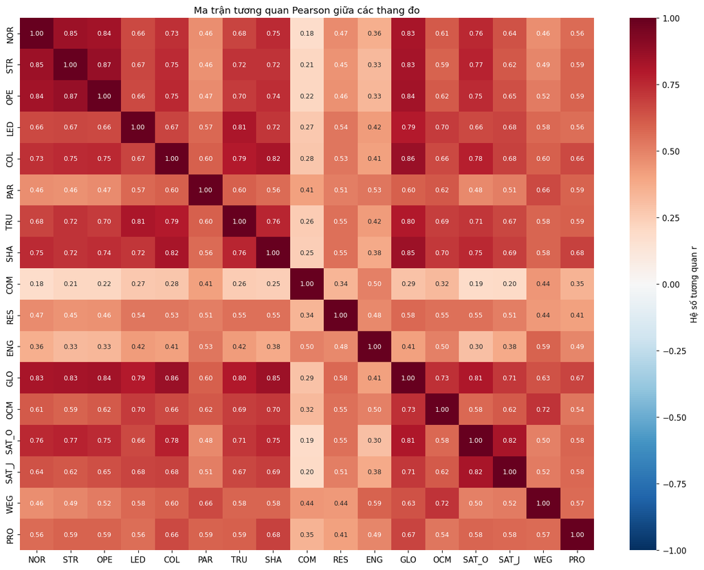

```python
corr = df[comps].corr().round(3)
corr.index = corr.columns = list(CONSTRUCTS.keys())
corr.to_csv(f'{OUT}/bang_tuong_quan.csv', encoding='utf-8-sig')
plt.figure(figsize=(13, 10))
sns.heatmap(corr, annot=True, fmt='.2f', cmap='RdBu_r', center=0, vmin=-1, vmax=1,
            annot_kws={'size': 8}, cbar_kws={'label': 'Hệ số tương quan r'})
plt.title('Ma trận tương quan Pearson giữa các thang đo')
plt.tight_layout(); plt.savefig(f'{OUT}/hinh_tuong_quan.png', bbox_inches='tight'); plt.show()
SUMMARY['corr_GLO'] = corr['GLO'].drop('GLO').round(3).to_dict()
```

## 9. Kiểm định khác biệt trung bình theo đặc điểm nhân khẩu học

Biến kiểm định chính: GLO (VHCL tổng thể) và các biến kết quả.

```python
df['Vai_tro'] = np.where(df['Nhom_CB'].isin([1, 2]), 'Giáo viên', 'CBQL')
df['Quoc_tich'] = np.where(df['Nhom_CB'].isin([1, 3]), 'Người Việt', 'Người nước ngoài')
test_vars = ['GLO_c','OCM_c','SAT_J_c','SAT_O_c','WEG_c','PRO_c']
rows = []
for gv, name in [('Vai_tro','GV vs CBQL'), ('Quoc_tich','Việt vs Nước ngoài'), ('Gioi_tinh','Nam vs Nữ')]:
    groups = df[gv].unique()
    for tv in test_vars:
        g1 = df.loc[df[gv] == groups[0], tv]; g2 = df.loc[df[gv] == groups[1], tv]
        tt = pg.ttest(g1, g2)
        rows.append({'So sánh': name, 'Biến': tv[:-2],
                     f'TB nhóm 1 ({groups[0]})': round(g1.mean(), 2), f'TB nhóm 2 ({groups[1]})': round(g2.mean(), 2),
                     't': round(tt['T'].iloc[0], 3), 'p': round(tt['p_val'].iloc[0], 4),
                     "Cohen d": round(tt['cohen_d'].iloc[0], 3)})
ttest_df = pd.DataFrame(rows)
ttest_df.to_csv(f'{OUT}/bang_ttest.csv', index=False, encoding='utf-8-sig')
SUMMARY['ttest'] = ttest_df.to_dict('records')
ttest_df
```

|  | So sánh | Biến | TB nhóm 1 (Giáo viên) | TB nhóm 2 (CBQL) | t | p | Cohen d | TB nhóm 1 (Người Việt) | TB nhóm 2 (Người nước ngoài) | TB nhóm 1 (1) | TB nhóm 2 (0) |
| --- | --- | --- | --- | --- | --- | --- | --- | --- | --- | --- | --- |
| 0 | GV vs CBQL | GLO | 4.52 | 4.81 | -2.034 | 0.0458 | 0.301 | NaN | NaN | NaN | NaN |
| 1 | GV vs CBQL | OCM | 4.79 | 5.06 | -2.226 | 0.0286 | 0.273 | NaN | NaN | NaN | NaN |
| 2 | GV vs CBQL | SAT_J | 3.83 | 3.88 | -0.543 | 0.5890 | 0.081 | NaN | NaN | NaN | NaN |
| 3 | GV vs CBQL | SAT_O | 3.67 | 3.62 | 0.376 | 0.7081 | 0.066 | NaN | NaN | NaN | NaN |
| 4 | GV vs CBQL | WEG | 4.65 | 4.80 | -1.425 | 0.1583 | 0.200 | NaN | NaN | NaN | NaN |
| 5 | GV vs CBQL | PRO | 4.86 | 4.79 | 0.503 | 0.6174 | 0.101 | NaN | NaN | NaN | NaN |
| 6 | Việt vs Nước ngoài | GLO | NaN | NaN | 7.423 | 0.0000 | 2.084 | 4.78 | 3.12 | NaN | NaN |
| 7 | Việt vs Nước ngoài | OCM | NaN | NaN | 6.046 | 0.0000 | 1.633 | 5.01 | 3.59 | NaN | NaN |
| 8 | Việt vs Nước ngoài | SAT_J | NaN | NaN | 7.062 | 0.0000 | 1.645 | 3.96 | 3.01 | NaN | NaN |
| 9 | Việt vs Nước ngoài | SAT_O | NaN | NaN | 8.120 | 0.0000 | 1.983 | 3.82 | 2.58 | NaN | NaN |
| 10 | Việt vs Nước ngoài | WEG | NaN | NaN | 3.856 | 0.0004 | 0.807 | 4.75 | 4.17 | NaN | NaN |
| 11 | Việt vs Nước ngoài | PRO | NaN | NaN | 4.839 | 0.0000 | 1.086 | 4.94 | 4.23 | NaN | NaN |
| 12 | Nam vs Nữ | GLO | NaN | NaN | 2.163 | 0.0328 | 0.330 | NaN | NaN | 4.65 | 4.33 |
| 13 | Nam vs Nữ | OCM | NaN | NaN | 2.900 | 0.0045 | 0.433 | NaN | NaN | 4.94 | 4.52 |
| 14 | Nam vs Nữ | SAT_J | NaN | NaN | 1.524 | 0.1304 | 0.222 | NaN | NaN | 3.88 | 3.73 |
| 15 | Nam vs Nữ | SAT_O | NaN | NaN | 1.992 | 0.0491 | 0.307 | NaN | NaN | 3.72 | 3.49 |
| 16 | Nam vs Nữ | WEG | NaN | NaN | 1.541 | 0.1257 | 0.206 | NaN | NaN | 4.71 | 4.56 |
| 17 | Nam vs Nữ | PRO | NaN | NaN | 0.782 | 0.4357 | 0.111 | NaN | NaN | 4.87 | 4.79 |

```python
# ANOVA theo Trường, Thâm niên, Độ tuổi (biến GLO và các kết quả chính)
rows = []
for gv, name in [('Truong','Trường'), ('Thoi_gian_cong_tac','Thâm niên'), ('Do_tuoi','Độ tuổi'), ('Nhom_CB','Nhóm khách thể')]:
    for tv in test_vars:
        aov = pg.anova(data=df, dv=tv, between=gv, detailed=False)
        rows.append({'Yếu tố': name, 'Biến': tv[:-2], 'F': round(aov['F'].iloc[0], 3),
                     'p': round(aov['p_unc'].iloc[0], 4), 'eta2p': round(aov['np2'].iloc[0], 3)})
anova_df = pd.DataFrame(rows)
anova_df.to_csv(f'{OUT}/bang_anova.csv', index=False, encoding='utf-8-sig')
SUMMARY['anova'] = anova_df.to_dict('records')
print(anova_df.to_string(index=False))
sig = anova_df[anova_df['p'] < .05]
print('\nKhác biệt có ý nghĩa (p < .05):'); print(sig.to_string(index=False) if len(sig) else '(không có)')
```

```
        Yếu tố  Biến      F      p  eta2p
        Trường   GLO  5.978 0.0001  0.080
        Trường   OCM  0.916 0.4551  0.013
        Trường SAT_J  2.016 0.0925  0.028
        Trường SAT_O  8.087 0.0000  0.105
        Trường   WEG  2.169 0.0727  0.030
        Trường   PRO  2.484 0.0440  0.035
     Thâm niên   GLO  3.417 0.0095  0.047
     Thâm niên   OCM  2.162 0.0735  0.030
     Thâm niên SAT_J  2.467 0.0452  0.035
     Thâm niên SAT_O  3.536 0.0078  0.049
     Thâm niên   WEG  1.724 0.1449  0.024
     Thâm niên   PRO  2.052 0.0873  0.029
       Độ tuổi   GLO  1.321 0.2623  0.019
       Độ tuổi   OCM  0.250 0.9096  0.004
       Độ tuổi SAT_J  1.081 0.3663  0.015
       Độ tuổi SAT_O  1.262 0.2851  0.018
       Độ tuổi   WEG  1.206 0.3086  0.017
       Độ tuổi   PRO  0.742 0.5638  0.011
Nhóm khách thể   GLO 60.498 0.0000  0.396
Nhóm khách thể   OCM 40.759 0.0000  0.306
Nhóm khách thể SAT_J 32.642 0.0000  0.261
Nhóm khách thể SAT_O 44.737 0.0000  0.326
Nhóm khách thể   WEG  9.132 0.0000  0.090
Nhóm khách thể   PRO 12.254 0.0000  0.117

Khác biệt có ý nghĩa (p < .05):
        Yếu tố  Biến      F      p  eta2p
        Trường   GLO  5.978 0.0001  0.080
        Trường SAT_O  8.087 0.0000  0.105
        Trường   PRO  2.484 0.0440  0.035
     Thâm niên   GLO  3.417 0.0095  0.047
     Thâm niên SAT_J  2.467 0.0452  0.035
     Thâm niên SAT_O  3.536 0.0078  0.049
Nhóm khách thể   GLO 60.498 0.0000  0.396
Nhóm khách thể   OCM 40.759 0.0000  0.306
Nhóm khách thể SAT_J 32.642 0.0000  0.261
Nhóm khách thể SAT_O 44.737 0.0000  0.326
Nhóm khách thể   WEG  9.132 0.0000  0.090
Nhóm khách thể   PRO 12.254 0.0000  0.117
```

```python
# Post-hoc cho các khác biệt có ý nghĩa theo Trường (nếu có)
for tv in test_vars:
    aov_p = anova_df[(anova_df['Yếu tố']=='Trường') & (anova_df['Biến']==tv[:-2])]['p'].iloc[0]
    if aov_p < .05:
        ph = pg.pairwise_tukey(data=df, dv=tv, between='Truong')
        sig_ph = ph[ph['p_tukey'] < .05]
        if len(sig_ph):
            print('=== Post-hoc Tukey:', tv[:-2]); print(sig_ph[['A','B','diff','p_tukey']].round(3).to_string(index=False))
```

```
=== Post-hoc Tukey: GLO
 A  B   diff  p_tukey
 2  3 -0.648    0.003
 2  4 -0.783    0.000
=== Post-hoc Tukey: SAT_O
 A  B   diff  p_tukey
 1  2  0.430    0.018
 2  3 -0.564    0.000
 2  4 -0.725    0.000
 2  5 -0.422    0.018
```

## 10. Hồi quy bội

**Mô hình 1:** GLO ← 11 yếu tố thành phần (tiền đề của VHCL). **Mô hình 2:** Từng biến kết quả ← GLO.

```python
import statsmodels.api as sm
from statsmodels.stats.outliers_influence import variance_inflation_factor

X_cols = [c + '_c' for c in iv_constructs]
Xz = (df[X_cols] - df[X_cols].mean()) / df[X_cols].std()
yz = (df['GLO_c'] - df['GLO_c'].mean()) / df['GLO_c'].std()
X1 = sm.add_constant(Xz)
m1 = sm.OLS(yz, X1).fit()
vif = pd.Series([variance_inflation_factor(X1.values, i + 1) for i in range(len(X_cols))], index=X_cols)
reg1 = pd.DataFrame({'Beta chuẩn hóa': m1.params[1:].round(3), 't': m1.tvalues[1:].round(2),
                     'p': m1.pvalues[1:].round(4), 'VIF': vif.round(2)})
reg1.index = [i[:-2] for i in reg1.index]
reg1.to_csv(f'{OUT}/bang_hoi_quy_GLO.csv', encoding='utf-8-sig')
print(f'Mô hình 1: R2 = {m1.rsquared:.3f}, R2 hiệu chỉnh = {m1.rsquared_adj:.3f}, F = {m1.fvalue:.2f}, p < .001, Durbin-Watson = {sm.stats.durbin_watson(m1.resid):.2f}')
SUMMARY['reg_GLO'] = {'r2': round(m1.rsquared,3), 'r2adj': round(m1.rsquared_adj,3), 'f': round(m1.fvalue,2),
                      'betas': reg1.reset_index().rename(columns={'index':'Biến'}).to_dict('records')}
reg1
```

```
Mô hình 1: R2 = 0.894, R2 hiệu chỉnh = 0.890, F = 206.55, p < .001, Durbin-Watson = 1.80
```

|  | Beta chuẩn hóa | t | p | VIF |
| --- | --- | --- | --- | --- |
| NOR | 0.116 | 2.67 | 0.0080 | 4.78 |
| STR | 0.120 | 2.52 | 0.0124 | 5.79 |
| OPE | 0.158 | 3.52 | 0.0005 | 5.13 |
| LED | 0.214 | 5.78 | 0.0000 | 3.50 |
| COL | 0.264 | 6.26 | 0.0000 | 4.51 |
| PAR | 0.040 | 1.42 | 0.1572 | 2.07 |
| TRU | -0.038 | -0.89 | 0.3748 | 4.68 |
| SHA | 0.174 | 4.34 | 0.0000 | 4.11 |
| COM | 0.033 | 1.39 | 0.1652 | 1.42 |
| RES | 0.052 | 1.98 | 0.0486 | 1.76 |
| ENG | -0.035 | -1.34 | 0.1807 | 1.76 |

### Trực quan hóa — hồi quy tiền đề → GLO

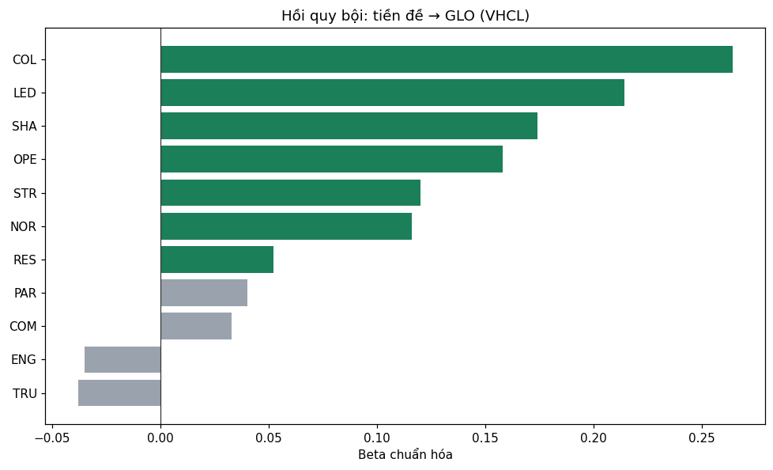

```python
# === VISUALIZATION CELL ===
fig, ax = plt.subplots(figsize=(9, 5.5))
ord_r = reg1.sort_values('Beta chuẩn hóa')
cols = ['#1b7f5a' if (str(p).startswith('<') or float(p) < .05) else '#9aa3ad' for p in ord_r['p']]
ax.barh(ord_r.index.astype(str), ord_r['Beta chuẩn hóa'], color=cols)
ax.axvline(0, color='#333', lw=.8)
ax.set_xlabel('Beta chuẩn hóa'); ax.set_title('Hồi quy bội: tiền đề → GLO (VHCL)')
plt.tight_layout(); plt.savefig(f'{OUT}/hinh_hoi_quy_GLO.png', bbox_inches='tight'); plt.show()
```

```python
# Mô hình 2: các kết quả của VHCL
rows = []
for dv in ['OCM','SAT_O','SAT_J','WEG','PRO']:
    yz2 = (df[dv + '_c'] - df[dv + '_c'].mean()) / df[dv + '_c'].std()
    xz2 = sm.add_constant((df['GLO_c'] - df['GLO_c'].mean()) / df['GLO_c'].std())
    m = sm.OLS(yz2, xz2).fit()
    rows.append({'Biến phụ thuộc': dv + ' — ' + TEN_VN[dv], 'Beta (GLO)': round(m.params.iloc[1], 3),
                 't': round(m.tvalues.iloc[1], 2), 'p': round(m.pvalues.iloc[1], 4), 'R2': round(m.rsquared, 3)})
reg2 = pd.DataFrame(rows)
reg2.to_csv(f'{OUT}/bang_hoi_quy_ket_qua.csv', index=False, encoding='utf-8-sig')
SUMMARY['reg_outcomes'] = reg2.to_dict('records')
reg2
```

|  | Biến phụ thuộc | Beta (GLO) | t | p | R2 |
| --- | --- | --- | --- | --- | --- |
| 0 | OCM — Cam kết tổ chức | 0.732 | 17.96 | 0.0 | 0.536 |
| 1 | SAT_O — Hài lòng với tổ chức | 0.809 | 23.02 | 0.0 | 0.655 |
| 2 | SAT_J — Hài lòng với công việc | 0.710 | 16.83 | 0.0 | 0.504 |
| 3 | WEG — Gắn kết công việc | 0.633 | 13.67 | 0.0 | 0.401 |
| 4 | PRO — Phát triển chuyên môn | 0.672 | 15.17 | 0.0 | 0.452 |

## 11. Mô hình đường dẫn H1–H6 (Path analysis, semopy)

Kiểm định đồng thời hệ thống giả thuyết trên biến đại diện:

- H1: NOR, STR, OPE → LED, COL, PAR
- H2: LED, COL, PAR → TRU, SHA
- H3: TRU, SHA → COM, RES, ENG
- H4: COM, RES, ENG → GLO
- H5: GLO → OCM, SAT_O, SAT_J, WEG, PRO
- H6: LED, COL, PAR → GLO (đường trực tiếp)

```python
import semopy
pdata = df[comps].copy()
pdata.columns = list(CONSTRUCTS.keys())
pdata = (pdata - pdata.mean()) / pdata.std()  # chuẩn hóa để đọc beta

MODEL = '''
LED ~ NOR + STR + OPE
COL ~ NOR + STR + OPE
PAR ~ NOR + STR + OPE
TRU ~ LED + COL + PAR
SHA ~ LED + COL + PAR
COM ~ TRU + SHA
RES ~ TRU + SHA
ENG ~ TRU + SHA
GLO ~ COM + RES + ENG + LED + COL + PAR
OCM ~ GLO
SAT_O ~ GLO
SAT_J ~ GLO
WEG ~ GLO
PRO ~ GLO
'''
# Mô hình hiệu chỉnh: bổ sung hiệp phương sai phần dư giữa các biến cùng cấp
# (thông lệ khi các khái niệm cùng tầng lý thuyết có tương quan; Kline, 2016)
COV = '''
LED ~~ COL
LED ~~ PAR
COL ~~ PAR
TRU ~~ SHA
COM ~~ RES
COM ~~ ENG
RES ~~ ENG
OCM ~~ SAT_O
OCM ~~ SAT_J
OCM ~~ WEG
OCM ~~ PRO
SAT_O ~~ SAT_J
SAT_O ~~ WEG
SAT_O ~~ PRO
SAT_J ~~ WEG
SAT_J ~~ PRO
WEG ~~ PRO
'''
m_base = semopy.Model(MODEL); m_base.fit(pdata)
fit_base = semopy.calc_stats(m_base)
pm = semopy.Model(MODEL + COV)
pm.fit(pdata)
est = pm.inspect(std_est=True)
paths = est[(est['op'] == '~')][['lval','op','rval','Est. Std','p-value']].copy()
paths.columns = ['Biến phụ thuộc','~','Biến độc lập','Beta chuẩn hóa','p']
paths['Beta chuẩn hóa'] = paths['Beta chuẩn hóa'].astype(float).round(3)
paths['p'] = paths['p'].apply(lambda x: '<.001' if float(x) < .001 else round(float(x), 4))
paths['Kết luận'] = paths.apply(lambda r: 'Có ý nghĩa' if (r['p'] == '<.001' or float(r['p']) < .05) else 'Không có ý nghĩa', axis=1)
stats_fit = semopy.calc_stats(pm)
fit_cmp = pd.DataFrame({
    'Mô hình gốc (H1–H6)': {k: round(float(fit_base[k].iloc[0]), 3) for k in ['chi2','DoF','CFI','TLI','RMSEA','GFI','AIC']},
    'Mô hình hiệu chỉnh (+ hiệp phương sai cùng cấp)': {k: round(float(stats_fit[k].iloc[0]), 3) for k in ['chi2','DoF','CFI','TLI','RMSEA','GFI','AIC']},
}).T
print(fit_cmp.to_string())
fit_cmp.to_csv(f'{OUT}/bang_do_phu_hop.csv', encoding='utf-8-sig')
paths.to_csv(f'{OUT}/bang_path_model.csv', index=False, encoding='utf-8-sig')
SUMMARY['path_fit'] = fit_cmp.to_dict('index')
SUMMARY['paths'] = paths.to_dict('records')
paths
```

```
                                                     chi2    DoF    CFI    TLI  RMSEA    GFI      AIC
Mô hình gốc (H1–H6)                              1021.642  107.0  0.806  0.749  0.175  0.790   84.729
Mô hình hiệu chỉnh (+ hiệp phương sai cùng cấp)   567.649   90.0  0.899  0.844  0.138  0.883  121.960
```

|  | Biến phụ thuộc | ~ | Biến độc lập | Beta chuẩn hóa | p | Kết luận |
| --- | --- | --- | --- | --- | --- | --- |
| 0 | LED | ~ | NOR | 0.267 | 0.0024 | Có ý nghĩa |
| 1 | LED | ~ | STR | 0.223 | 0.0232 | Có ý nghĩa |
| 2 | LED | ~ | OPE | 0.246 | 0.008 | Có ý nghĩa |
| 3 | COL | ~ | NOR | 0.231 | 0.0025 | Có ý nghĩa |
| 4 | COL | ~ | STR | 0.266 | 0.0019 | Có ý nghĩa |
| 5 | COL | ~ | OPE | 0.326 | <.001 | Có ý nghĩa |
| 6 | PAR | ~ | NOR | 0.186 | 0.0837 | Không có ý nghĩa |
| 7 | PAR | ~ | STR | 0.096 | 0.4225 | Không có ý nghĩa |
| 8 | PAR | ~ | OPE | 0.232 | 0.0406 | Có ý nghĩa |
| 9 | TRU | ~ | LED | 0.497 | <.001 | Có ý nghĩa |
| 10 | TRU | ~ | COL | 0.419 | <.001 | Có ý nghĩa |
| 11 | TRU | ~ | PAR | 0.064 | 0.0854 | Không có ý nghĩa |
| 12 | SHA | ~ | LED | 0.293 | <.001 | Có ý nghĩa |
| 13 | SHA | ~ | COL | 0.605 | <.001 | Có ý nghĩa |
| 14 | SHA | ~ | PAR | 0.032 | 0.4315 | Không có ý nghĩa |
| 15 | COM | ~ | TRU | 0.161 | 0.069 | Không có ý nghĩa |
| 16 | COM | ~ | SHA | 0.125 | 0.1568 | Không có ý nghĩa |
| 17 | RES | ~ | TRU | 0.323 | <.001 | Có ý nghĩa |
| 18 | RES | ~ | SHA | 0.301 | <.001 | Có ý nghĩa |
| 19 | ENG | ~ | TRU | 0.329 | <.001 | Có ý nghĩa |
| 20 | ENG | ~ | SHA | 0.125 | 0.1331 | Không có ý nghĩa |
| 21 | GLO | ~ | COM | 0.024 | 0.4086 | Không có ý nghĩa |
| 22 | GLO | ~ | RES | 0.077 | 0.0145 | Có ý nghĩa |
| 23 | GLO | ~ | ENG | -0.038 | 0.2244 | Không có ý nghĩa |
| 24 | GLO | ~ | LED | 0.367 | <.001 | Có ý nghĩa |
| 25 | GLO | ~ | COL | 0.572 | <.001 | Có ý nghĩa |
| 26 | GLO | ~ | PAR | 0.020 | 0.5283 | Không có ý nghĩa |
| 27 | OCM | ~ | GLO | 0.731 | <.001 | Có ý nghĩa |
| 28 | SAT_O | ~ | GLO | 0.809 | <.001 | Có ý nghĩa |
| 29 | SAT_J | ~ | GLO | 0.709 | <.001 | Có ý nghĩa |
| 30 | WEG | ~ | GLO | 0.632 | <.001 | Có ý nghĩa |
| 31 | PRO | ~ | GLO | 0.671 | <.001 | Có ý nghĩa |

```python
# R2 của các biến nội sinh trong mô hình đường dẫn
endo = ['LED','COL','PAR','TRU','SHA','COM','RES','ENG','GLO','OCM','SAT_O','SAT_J','WEG','PRO']
r2_rows = []
for e in endo:
    preds = [r['Biến độc lập'] for r in paths.to_dict('records') if r['Biến phụ thuộc'] == e]
    m = sm.OLS(pdata[e], sm.add_constant(pdata[preds])).fit()
    r2_rows.append({'Biến': e, 'R2': round(m.rsquared, 3)})
r2_df = pd.DataFrame(r2_rows)
r2_df.to_csv(f'{OUT}/bang_r2.csv', index=False, encoding='utf-8-sig')
SUMMARY['r2'] = r2_df.to_dict('records')
r2_df
```

|  | Biến | R2 |
| --- | --- | --- |
| 0 | LED | 0.490 |
| 1 | COL | 0.614 |
| 2 | PAR | 0.239 |
| 3 | TRU | 0.775 |
| 4 | SHA | 0.726 |
| 5 | COM | 0.072 |
| 6 | RES | 0.343 |
| 7 | ENG | 0.186 |
| 8 | GLO | 0.830 |
| 9 | OCM | 0.536 |
| 10 | SAT_O | 0.655 |
| 11 | SAT_J | 0.504 |
| 12 | WEG | 0.401 |
| 13 | PRO | 0.452 |

### Trực quan hóa — mô hình đường dẫn (semopy)

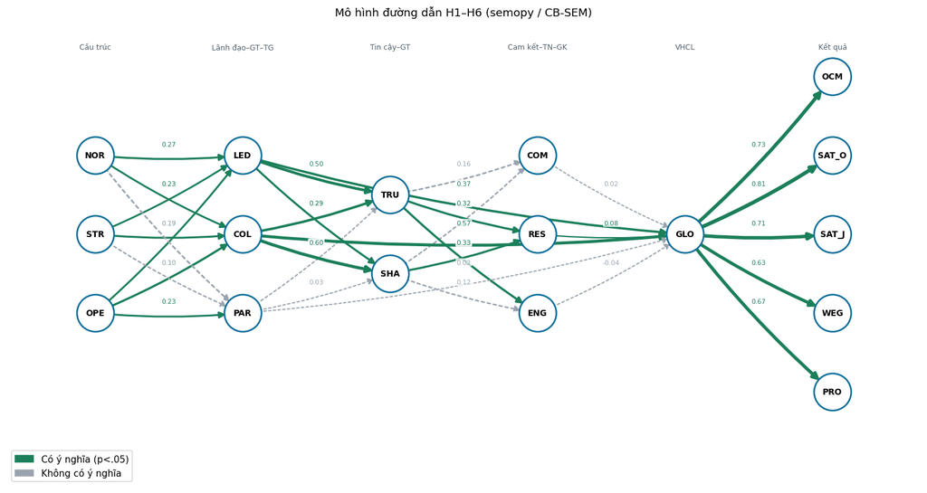

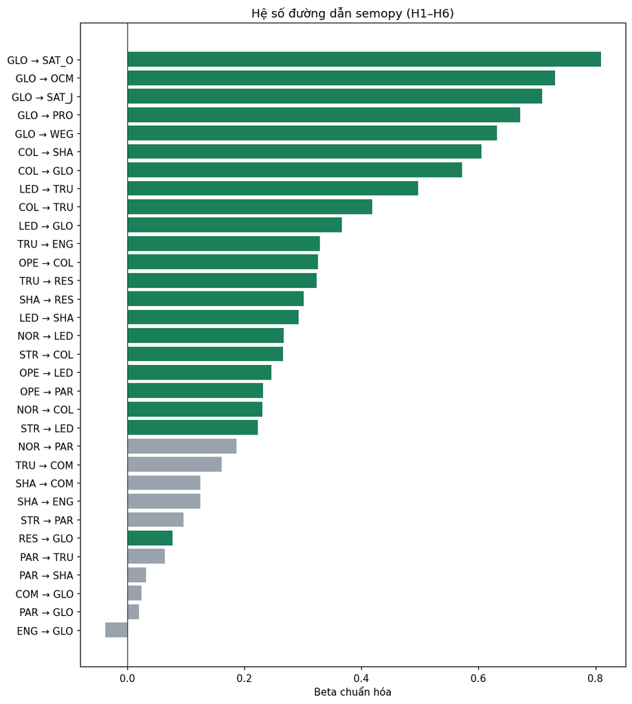

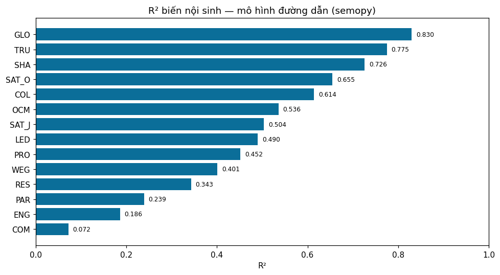

```python
# === VISUALIZATION CELL ===
# Helper vẽ sơ đồ path H1–H6 (dùng lại cho semopy & PLS)
import networkx as nx
import matplotlib.patches as mpatches

_LAYERS = [
    ['NOR', 'STR', 'OPE'],
    ['LED', 'COL', 'PAR'],
    ['TRU', 'SHA'],
    ['COM', 'RES', 'ENG'],
    ['GLO'],
    ['OCM', 'SAT_O', 'SAT_J', 'WEG', 'PRO'],
]
_LAYER_CAP = ['Cấu trúc', 'Lãnh đạo–GT–TG', 'Tin cậy–GT', 'Cam kết–TN–GK', 'VHCL', 'Kết quả']
_C_OK, _C_NS, _C_ACC, _C_BG = '#1b7f5a', '#9aa3ad', '#0b6e99', '#f7f9fb'

def ve_so_do_path(path_df, beta_col, from_col, to_col, sig_col, title, outfile):
    G = nx.DiGraph(); pos = {}
    for xi, layer in enumerate(_LAYERS):
        n = len(layer)
        for yi, node in enumerate(layer):
            G.add_node(node); pos[node] = (xi, (n - 1) / 2 - yi)
    edges = []
    for _, r in path_df.iterrows():
        u, v = r[from_col], r[to_col]
        if u not in G or v not in G: continue
        sig = str(r[sig_col]); is_sig = 'Có' in sig
        edges.append((u, v, float(r[beta_col]), is_sig))
    fig, ax = plt.subplots(figsize=(14, 7.5)); ax.set_facecolor(_C_BG)
    nx.draw_networkx_nodes(G, pos, node_size=1600, node_color='white', edgecolors=_C_ACC, linewidths=1.8, ax=ax)
    nx.draw_networkx_labels(G, pos, font_size=9, font_weight='bold', ax=ax)
    for u, v, beta, is_sig in edges:
        color = _C_OK if is_sig else _C_NS
        nx.draw_networkx_edges(G, pos, edgelist=[(u, v)], width=1.2 + 3.5 * abs(beta),
            edge_color=color, arrows=True, arrowsize=14, connectionstyle='arc3,rad=0.05',
            style='solid' if is_sig else (0, (2, 2)), ax=ax, min_source_margin=18, min_target_margin=18)
        x1, y1 = pos[u]; x2, y2 = pos[v]
        ax.text((x1 + x2) / 2, (y1 + y2) / 2 + 0.12, f'{beta:.2f}', fontsize=7, color=color, ha='center',
                bbox=dict(boxstyle='round,pad=0.15', fc='white', ec='none', alpha=0.75))
    for xi, cap in enumerate(_LAYER_CAP):
        ax.text(xi, 2.35, cap, ha='center', fontsize=8, color='#52606d')
    ax.set_title(title); ax.axis('off'); ax.set_xlim(-0.6, 5.6); ax.set_ylim(-3.2, 2.7)
    ax.legend(handles=[mpatches.Patch(color=_C_OK, label='Có ý nghĩa (p<.05)'),
                       mpatches.Patch(color=_C_NS, label='Không có ý nghĩa')], loc='lower left')
    plt.tight_layout(); plt.savefig(f'{OUT}/{outfile}', bbox_inches='tight'); plt.show()


ve_so_do_path(paths, 'Beta chuẩn hóa', 'Biến độc lập', 'Biến phụ thuộc', 'Kết luận',
              'Mô hình đường dẫn H1–H6 (semopy / CB-SEM)', 'hinh_mo_hinh_path_semopy.png')

fig, ax = plt.subplots(figsize=(9, 10))
pf = paths.copy()
pf['label'] = pf['Biến độc lập'] + ' → ' + pf['Biến phụ thuộc']
pf = pf.sort_values('Beta chuẩn hóa')
cols = ['#1b7f5a' if 'Có' in str(s) else '#9aa3ad' for s in pf['Kết luận']]
ax.barh(pf['label'], pf['Beta chuẩn hóa'], color=cols)
ax.axvline(0, color='#333', lw=.8)
ax.set_xlabel('Beta chuẩn hóa'); ax.set_title('Hệ số đường dẫn semopy (H1–H6)')
plt.tight_layout(); plt.savefig(f'{OUT}/hinh_path_betas_semopy.png', bbox_inches='tight'); plt.show()

fig, ax = plt.subplots(figsize=(9, 5))
ord2 = r2_df.sort_values('R2')
ax.barh(ord2['Biến'].astype(str), ord2['R2'], color='#0b6e99')
ax.set_xlim(0, 1); ax.set_xlabel('R²'); ax.set_title('R² biến nội sinh — mô hình đường dẫn (semopy)')
for y, v in enumerate(ord2['R2']):
    ax.text(v + .01, y, f'{v:.3f}', va='center', fontsize=8)
plt.tight_layout(); plt.savefig(f'{OUT}/hinh_r2_semopy.png', bbox_inches='tight'); plt.show()
```

### Mô hình cạnh tranh

So sánh: **M1** — mô hình gốc H1–H6; **M2** — M1 + hiệp phương sai cùng cấp (mô hình chính); **M3** — M2 + đường trực tiếp NOR/STR/OPE → GLO; **M4** — mô hình tiết kiệm xử lí giá trị phân biệt (gộp NOR+STR+OPE thành STRUC; gộp SAT_O+SAT_J thành SAT).

```python
from scipy import stats as scistats
pdata2 = pdata.copy()
pdata2['STRUC'] = df[CONSTRUCTS['NOR'] + CONSTRUCTS['STR'] + CONSTRUCTS['OPE']].mean(axis=1)
pdata2['SAT'] = df[CONSTRUCTS['SAT_O'] + CONSTRUCTS['SAT_J']].mean(axis=1)
for c in ['STRUC', 'SAT']:
    pdata2[c] = (pdata2[c] - pdata2[c].mean()) / pdata2[c].std()

M3_SPEC = (MODEL + COV).replace('GLO ~ COM + RES + ENG + LED + COL + PAR',
                                'GLO ~ COM + RES + ENG + LED + COL + PAR + NOR + STR + OPE')
M4_LINES = ['LED ~ STRUC', 'COL ~ STRUC', 'PAR ~ STRUC',
            'TRU ~ LED + COL + PAR', 'SHA ~ LED + COL + PAR',
            'COM ~ TRU + SHA', 'RES ~ TRU + SHA', 'ENG ~ TRU + SHA',
            'GLO ~ COM + RES + ENG + LED + COL + PAR + STRUC',
            'SAT ~ GLO', 'OCM ~ GLO', 'WEG ~ GLO', 'PRO ~ GLO',
            'LED ~~ COL', 'LED ~~ PAR', 'COL ~~ PAR', 'TRU ~~ SHA',
            'COM ~~ RES', 'COM ~~ ENG', 'RES ~~ ENG',
            'OCM ~~ SAT', 'OCM ~~ WEG', 'OCM ~~ PRO',
            'SAT ~~ WEG', 'SAT ~~ PRO', 'WEG ~~ PRO']
M4_SPEC = chr(10).join(M4_LINES)

cmp_rows = []
models_cmp = {}
for name, spec in [('M1 — gốc H1–H6', MODEL), ('M2 — hiệu chỉnh (chính)', MODEL + COV),
                   ('M3 — M2 + cấu trúc → GLO', M3_SPEC), ('M4 — tiết kiệm (STRUC, SAT)', M4_SPEC)]:
    mm = semopy.Model(spec); mm.fit(pdata2)
    ss = semopy.calc_stats(mm)
    models_cmp[name] = mm
    cmp_rows.append({'Mô hình': name, **{k: round(float(ss[k].iloc[0]), 3) for k in ['chi2','DoF','CFI','TLI','RMSEA','GFI']}})
cmp_df = pd.DataFrame(cmp_rows)
cmp_df.to_csv(f'{OUT}/bang_mo_hinh_canh_tranh.csv', index=False, encoding='utf-8-sig')
SUMMARY['model_compare'] = cmp_df.to_dict('records')
c2, d2 = cmp_rows[1]['chi2'], cmp_rows[1]['DoF']
c3, d3 = cmp_rows[2]['chi2'], cmp_rows[2]['DoF']
dchi, ddf = c2 - c3, int(d2 - d3)
p_d = scistats.chi2.sf(dchi, ddf)
SUMMARY['delta_chi2'] = {'delta': round(dchi, 1), 'ddf': ddf, 'p': float(p_d)}
print(f'So sánh M2 với M3 (lồng nhau): Δχ² = {dchi:.1f}, Δdf = {ddf}, p = {p_d:.2e}')
cmp_df
```

```
So sánh M2 với M3 (lồng nhau): Δχ² = 113.9, Δdf = 3, p = 1.55e-24
```

|  | Mô hình | chi2 | DoF | CFI | TLI | RMSEA | GFI |
| --- | --- | --- | --- | --- | --- | --- | --- |
| 0 | M1 — gốc H1–H6 | 1021.642 | 107.0 | 0.806 | 0.749 | 0.175 | 0.790 |
| 1 | M2 — hiệu chỉnh (chính) | 567.649 | 90.0 | 0.899 | 0.844 | 0.138 | 0.883 |
| 2 | M3 — M2 + cấu trúc → GLO | 453.701 | 87.0 | 0.922 | 0.876 | 0.123 | 0.907 |
| 3 | M4 — tiết kiệm (STRUC, SAT) | 378.589 | 53.0 | 0.908 | 0.840 | 0.148 | 0.895 |

```python
# Hệ số đường dẫn của GLO trong M3
e3 = models_cmp['M3 — M2 + cấu trúc → GLO'].inspect(std_est=True)
p3 = e3[(e3['op'] == '~') & (e3['lval'] == 'GLO')][['rval', 'Est. Std', 'p-value']].copy()
p3.columns = ['Biến độc lập', 'Beta chuẩn hóa', 'p']
p3['Beta chuẩn hóa'] = p3['Beta chuẩn hóa'].astype(float).round(3)
p3['p'] = p3['p'].apply(lambda x: '<.001' if float(x) < .001 else round(float(x), 4))
p3.to_csv(f'{OUT}/bang_m3_glo_paths.csv', index=False, encoding='utf-8-sig')
SUMMARY['m3_glo_paths'] = p3.to_dict('records')
p3
```

|  | Biến độc lập | Beta chuẩn hóa | p |
| --- | --- | --- | --- |
| 21 | COM | 0.034 | 0.1434 |
| 22 | RES | 0.065 | 0.012 |
| 23 | ENG | -0.044 | 0.0845 |
| 24 | LED | 0.231 | <.001 |
| 25 | COL | 0.329 | <.001 |
| 26 | PAR | 0.046 | 0.0828 |
| 27 | NOR | 0.153 | <.001 |
| 28 | STR | 0.106 | 0.0253 |
| 29 | OPE | 0.178 | <.001 |

```python
# Kiểm tra tính vững: COL -> GLO khi loại GLO4, GLO5 (item trùng nội dung giao tiếp)
glo_r_items = ['GLO1', 'GLO2', 'GLO3', 'GLO6', 'GLO7', 'GLO8']
glo_r = df[glo_r_items].mean(axis=1)
glo_r = (glo_r - glo_r.mean()) / glo_r.std()
Xr = pdata2[['COM', 'RES', 'ENG', 'LED', 'COL', 'PAR', 'NOR', 'STR', 'OPE']]
mr = sm.OLS(glo_r, sm.add_constant(Xr)).fit()
rob = pd.DataFrame({'Beta': mr.params[1:].round(3), 'p': mr.pvalues[1:].round(4)})
rob.to_csv(f'{OUT}/bang_robustness_GLO_rut_gon.csv', encoding='utf-8-sig')
SUMMARY['robustness_col'] = {'COL_beta': round(float(mr.params['COL']), 3), 'COL_p': round(float(mr.pvalues['COL']), 4),
                             'LED_beta': round(float(mr.params['LED']), 3), 'r2': round(float(mr.rsquared), 3)}
print(f"GLO rút gọn (bỏ GLO4, GLO5): R2 = {mr.rsquared:.3f}; COL vẫn có ý nghĩa: beta = {mr.params['COL']:.3f}, p = {mr.pvalues['COL']:.4f}")
rob
```

```
GLO rút gọn (bỏ GLO4, GLO5): R2 = 0.862; COL vẫn có ý nghĩa: beta = 0.237, p = 0.0000
```

|  | Beta | p |
| --- | --- | --- |
| COM | 0.032 | 0.2376 |
| RES | 0.045 | 0.1298 |
| ENG | -0.048 | 0.1075 |
| LED | 0.235 | 0.0000 |
| COL | 0.237 | 0.0000 |
| PAR | 0.046 | 0.1541 |
| NOR | 0.220 | 0.0000 |
| STR | 0.124 | 0.0206 |
| OPE | 0.181 | 0.0004 |

### SEM đầy đủ (biến tiềm ẩn) — kiểm chứng bổ sung (tùy chọn)

```python
RUN_FULL_SEM = True  # đổi thành True để chạy SEM đầy đủ (mất vài phút)
if RUN_FULL_SEM:
    meas = '\n'.join(f"{c} =~ " + ' + '.join(items) for c, items in CONSTRUCTS.items())
    FULL = meas + '\n' + MODEL
    fm = semopy.Model(FULL)
    fm.fit(df[all_items])
    fstats = semopy.calc_stats(fm)
    print(fstats.T.round(3).to_string())
    fe = fm.inspect(std_est=True)
    fpaths = fe[(fe['op'] == '~')][['lval','rval','Est. Std','p-value']]
    fpaths.to_csv(f'{OUT}/bang_sem_full.csv', index=False, encoding='utf-8-sig')
else:
    print('Bỏ qua SEM đầy đủ (RUN_FULL_SEM = False).')
```

```
                   Value
DoF             3204.000
DoF Baseline    3321.000
chi2            8257.155
chi2 p-value       0.000
chi2 Baseline  26025.108
CFI                0.777
GFI                0.683
AGFI               0.671
NFI                0.683
TLI                0.769
RMSEA              0.075
AIC              339.230
BIC             1063.263
LogLik            29.385
```

## 11b. PLS-SEM (plspm) — cùng cấu trúc H1–H6

Ước lượng **variance-based PLS-SEM** (Mode A phản ánh, scheme PATH) trên toàn bộ biến quan sát, cùng sơ đồ giả thuyết với mô hình đường dẫn `semopy`. Thư viện: `plspm` (tương thích kết quả kiểu SmartPLS / seminR).

**Báo cáo:** (1) mô hình đo lường — loading, α, ρA/DG.rho, AVE; (2) mô hình cấu trúc — β, t, p, R², f², GoF; (3) bootstrap tuần tự (tránh lỗi multiprocessing trên Windows).

```python
# PLS-SEM: cấu hình mô hình đo lường + cấu trúc H1–H6
import plspm.config as c
from plspm.plspm import Plspm
from plspm.scheme import Scheme
from plspm.mode import Mode
from plspm.config import MV

PLS_BOOT = 500  # tăng lên 1000-5000 nếu cần CI ổn định hơn (mỗi lần ~0.4s)

pls_items = [i for v in CONSTRUCTS.values() for i in v]
pls_df = df[pls_items].astype(float).copy()

def build_pls_config():
    structure = c.Structure()
    for tgt in ['LED', 'COL', 'PAR']:
        structure.add_path(['NOR', 'STR', 'OPE'], [tgt])   # H1
    for tgt in ['TRU', 'SHA']:
        structure.add_path(['LED', 'COL', 'PAR'], [tgt])   # H2
    for tgt in ['COM', 'RES', 'ENG']:
        structure.add_path(['TRU', 'SHA'], [tgt])          # H3
    structure.add_path(['COM', 'RES', 'ENG', 'LED', 'COL', 'PAR'], ['GLO'])  # H4 + H6
    for tgt in ['OCM', 'SAT_O', 'SAT_J', 'WEG', 'PRO']:
        structure.add_path(['GLO'], [tgt])                 # H5
    config = c.Config(structure.path(), scaled=True)
    for lv, items in CONSTRUCTS.items():
        config.add_lv(lv, Mode.A, *[MV(it) for it in items])
    return config

pls = Plspm(pls_df, build_pls_config(), Scheme.PATH, bootstrap=False)
print(f'GoF (Tenenhaus) = {pls.goodness_of_fit():.3f}')
print(f'Số quan sát = {len(pls_df)}, số biến quan sát = {len(pls_items)}, số khái niệm = {len(CONSTRUCTS)}')
```

```
GoF (Tenenhaus) = 0.588
Số quan sát = 281, số biến quan sát = 82, số khái niệm = 17
```

```python
# (1) Mô hình đo lường: loading ngoài, độ tin cậy, AVE
outer = pls.outer_model().copy()
outer = outer.reset_index().rename(columns={'index': 'Item'})
outer['Khái niệm'] = outer['Item'].map({it: c for c, items in CONSTRUCTS.items() for it in items})
outer['loading'] = outer['loading'].astype(float).round(3)
outer['Đạt loading≥.70'] = np.where(outer['loading'] >= .70, 'Đạt', 'Xem xét')
outer_out = outer[['Khái niệm', 'Item', 'loading', 'communality', 'Đạt loading≥.70']].copy()
outer_out['communality'] = outer_out['communality'].astype(float).round(3)
outer_out.to_csv(f'{OUT}/pls_outer_loadings.csv', index=False, encoding='utf-8-sig')

uni = pls.unidimensionality().copy()
uni = uni.rename(columns={'cronbach_alpha': 'Cronbach_alpha',
                          'dillon_goldstein_rho': 'DG_rho',
                          'eig_1st': 'eig1', 'eig_2nd': 'eig2'})
summary_inner = pls.inner_summary().copy()
meas = uni.join(summary_inner[['ave', 'r_squared']], how='left')
meas['sqrt_AVE'] = np.sqrt(meas['ave'])
meas = meas.round(3)
meas.insert(0, 'Tên', [TEN_VN.get(i, i) for i in meas.index])
meas['AVE≥.50'] = np.where(meas['ave'] >= .50, 'Đạt', 'Không đạt')
meas.to_csv(f'{OUT}/pls_measurement.csv', encoding='utf-8-sig')
SUMMARY['pls_gof'] = round(float(pls.goodness_of_fit()), 3)
SUMMARY['pls_measurement'] = meas.reset_index().rename(columns={'index': 'Mã'}).to_dict('records')
print('Loading < .70:', int((outer['loading'] < .70).sum()), '/', len(outer))
meas
```

```
Loading < .70: 14 / 82
```

|  | Tên | mode | mvs | Cronbach_alpha | DG_rho | eig1 | eig2 | ave | r_squared | sqrt_AVE | AVE≥.50 |
| --- | --- | --- | --- | --- | --- | --- | --- | --- | --- | --- | --- |
| OPE | Hành động | A | 3.0 | 0.889 | 0.931 | 2.455 | 0.305 | 0.818 | 0.000 | 0.905 | Đạt |
| STR | Chiến lược | A | 3.0 | 0.910 | 0.943 | 2.543 | 0.281 | 0.847 | 0.000 | 0.921 | Đạt |
| NOR | Chuẩn mực | A | 3.0 | 0.938 | 0.960 | 2.670 | 0.201 | 0.890 | 0.000 | 0.943 | Đạt |
| PAR | Tham gia | A | 4.0 | 0.764 | 0.850 | 2.351 | 0.682 | 0.581 | 0.257 | 0.762 | Đạt |
| COL | Giao tiếp | A | 6.0 | 0.909 | 0.931 | 4.152 | 0.820 | 0.685 | 0.634 | 0.828 | Đạt |
| LED | Lãnh đạo | A | 12.0 | 0.966 | 0.970 | 8.768 | 0.889 | 0.730 | 0.495 | 0.854 | Đạt |
| SHA | Các giá trị | A | 2.0 | 0.848 | 0.929 | 1.736 | 0.264 | 0.868 | 0.735 | 0.932 | Đạt |
| TRU | Niềm tin | A | 4.0 | 0.832 | 0.888 | 2.663 | 0.629 | 0.659 | 0.793 | 0.812 | Đạt |
| ENG | Gắn kết | A | 4.0 | 0.765 | 0.850 | 2.348 | 0.622 | 0.579 | 0.185 | 0.761 | Đạt |
| RES | Trách nhiệm | A | 2.0 | 0.766 | 0.895 | 1.621 | 0.379 | 0.809 | 0.344 | 0.900 | Đạt |
| COM | Cam kết | A | 3.0 | 0.764 | 0.865 | 2.044 | 0.603 | 0.674 | 0.099 | 0.821 | Đạt |
| GLO | Các khía cạnh tổng thể | A | 8.0 | 0.947 | 0.956 | 5.843 | 0.561 | 0.730 | 0.836 | 0.854 | Đạt |
| PRO | Phát triển chuyên môn | A | 6.0 | 0.839 | 0.882 | 3.333 | 0.989 | 0.517 | 0.561 | 0.719 | Đạt |
| WEG | Gắn kết công việc | A | 9.0 | 0.892 | 0.914 | 4.926 | 0.974 | 0.544 | 0.421 | 0.738 | Đạt |
| SAT_J | Hài lòng với công việc | A | 4.0 | 0.850 | 0.899 | 2.765 | 0.518 | 0.686 | 0.522 | 0.828 | Đạt |
| SAT_O | Hài lòng với tổ chức | A | 6.0 | 0.896 | 0.922 | 4.004 | 0.738 | 0.664 | 0.664 | 0.815 | Đạt |
| OCM | Cam kết tổ chức | A | 3.0 | 0.858 | 0.913 | 2.336 | 0.377 | 0.778 | 0.544 | 0.882 | Đạt |

```python
# Giá trị phân biệt PLS: Fornell–Larcker (căn AVE vs tương quan điểm tiềm ẩn)
scores = pls.scores()
lv_corr = scores.corr()
ave_s = pls.inner_summary()['ave']
fl_rows = []
for i, a in enumerate(lv_corr.columns):
    for b in lv_corr.columns[i+1:]:
        r = float(lv_corr.loc[a, b])
        thr = float(min(np.sqrt(ave_s[a]), np.sqrt(ave_s[b])))
        if r > thr:
            fl_rows.append({'Cặp': f'{a} – {b}', 'r_LV': round(r, 3), 'min_sqrt_AVE': round(thr, 3)})
pls_fl = pd.DataFrame(fl_rows)
pls_fl.to_csv(f'{OUT}/pls_fornell_larcker_viph.csv', index=False, encoding='utf-8-sig')
SUMMARY['pls_fl_violations'] = pls_fl.to_dict('records')
print('Số cặp vi phạm Fornell–Larcker (PLS):', len(pls_fl))
pls_fl.head(20) if len(pls_fl) else pls_fl
```

```
Số cặp vi phạm Fornell–Larcker (PLS): 7
```

|  | Cặp | r_LV | min_sqrt_AVE |
| --- | --- | --- | --- |
| 0 | COL – SHA | 0.834 | 0.828 |
| 1 | COL – GLO | 0.876 | 0.828 |
| 2 | LED – TRU | 0.840 | 0.812 |
| 3 | SHA – GLO | 0.856 | 0.854 |
| 4 | SHA – PRO | 0.731 | 0.719 |
| 5 | GLO – PRO | 0.749 | 0.719 |
| 6 | SAT_J – SAT_O | 0.827 | 0.815 |

```python
# (2) Mô hình cấu trúc: hệ số đường dẫn + R2 + f2
paths_pls = pls.inner_model().copy()
paths_pls = paths_pls.rename(columns={'from': 'Biến độc lập', 'to': 'Biến phụ thuộc',
                                      'estimate': 'Beta', 'std error': 'SE', 't': 't', 'p>|t|': 'p'})
paths_pls['Beta'] = paths_pls['Beta'].astype(float).round(3)
paths_pls['SE'] = paths_pls['SE'].astype(float).round(3)
paths_pls['t'] = paths_pls['t'].astype(float).round(2)
paths_pls['p_num'] = paths_pls['p'].astype(float)
paths_pls['p'] = paths_pls['p_num'].apply(lambda x: '<.001' if x < .001 else round(x, 4))
paths_pls['Kết luận'] = np.where(paths_pls['p_num'] < .05, 'Có ý nghĩa', 'Không có ý nghĩa')

# f-square trên điểm tiềm ẩn PLS (OLS tuần tự)
from numpy.linalg import lstsq
f2_vals = []
sc = scores.copy()
for _, r in paths_pls.iterrows():
    y, x = r['Biến phụ thuộc'], r['Biến độc lập']
    preds = list(paths_pls.loc[paths_pls['Biến phụ thuộc'] == y, 'Biến độc lập'])
    Y = sc[y].values
    X_full = np.column_stack([np.ones(len(sc)), sc[preds].values])
    if len(preds) > 1:
        X_red = np.column_stack([np.ones(len(sc)), sc[[p for p in preds if p != x]].values])
    else:
        X_red = np.ones((len(sc), 1))
    b_f, *_ = lstsq(X_full, Y, rcond=None)
    b_r, *_ = lstsq(X_red, Y, rcond=None)
    r2_f = 1 - np.sum((Y - X_full @ b_f)**2) / np.sum((Y - Y.mean())**2)
    r2_r = 1 - np.sum((Y - X_red @ b_r)**2) / np.sum((Y - Y.mean())**2)
    f2 = (r2_f - r2_r) / (1 - r2_f) if r2_f < .999 else np.nan
    f2_vals.append(f2)
paths_pls['f2'] = np.round(f2_vals, 3)
paths_pls['f2 mức'] = pd.cut(paths_pls['f2'], bins=[-np.inf, .02, .15, .35, np.inf],
                             labels=['không đáng kể', 'nhỏ', 'trung bình', 'lớn'])

r2_pls = pls.inner_summary().loc[pls.inner_summary()['type'] == 'Endogenous', ['r_squared']].round(3)
r2_pls = r2_pls.rename(columns={'r_squared': 'R2'})
r2_pls.insert(0, 'Tên', [TEN_VN.get(i, i) for i in r2_pls.index])
r2_pls.to_csv(f'{OUT}/pls_r2.csv', encoding='utf-8-sig')

out_paths = paths_pls[['Biến phụ thuộc', 'Biến độc lập', 'Beta', 'SE', 't', 'p', 'f2', 'f2 mức', 'Kết luận']].copy()
out_paths.to_csv(f'{OUT}/pls_paths.csv', index=False, encoding='utf-8-sig')
SUMMARY['pls_paths'] = out_paths.to_dict('records')
SUMMARY['pls_r2'] = r2_pls.reset_index().rename(columns={'index': 'Biến'}).to_dict('records')
print('R2 các biến nội sinh:')
display(r2_pls)
out_paths
```

```
R2 các biến nội sinh:
```

|  | Tên | R2 |
| --- | --- | --- |
| COL | Giao tiếp | 0.634 |
| COM | Cam kết | 0.099 |
| ENG | Gắn kết | 0.185 |
| GLO | Các khía cạnh tổng thể | 0.836 |
| LED | Lãnh đạo | 0.495 |
| OCM | Cam kết tổ chức | 0.544 |
| PAR | Tham gia | 0.257 |
| PRO | Phát triển chuyên môn | 0.561 |
| RES | Trách nhiệm | 0.344 |
| SAT_J | Hài lòng với công việc | 0.522 |
| SAT_O | Hài lòng với tổ chức | 0.664 |
| SHA | Các giá trị | 0.735 |
| TRU | Niềm tin | 0.793 |
| WEG | Gắn kết công việc | 0.421 |

| index | Biến phụ thuộc | Biến độc lập | Beta | SE | t | p | f2 | f2 mức | Kết luận |
| --- | --- | --- | --- | --- | --- | --- | --- | --- | --- |
| OPE -> PAR | PAR | OPE | 0.229 | 0.113 | 2.02 | 0.0447 | 0.015 | không đáng kể | Có ý nghĩa |
| STR -> PAR | PAR | STR | 0.105 | 0.120 | 0.88 | 0.3808 | 0.003 | không đáng kể | Không có ý nghĩa |
| NOR -> PAR | PAR | NOR | 0.198 | 0.107 | 1.86 | 0.0644 | 0.012 | không đáng kể | Không có ý nghĩa |
| OPE -> COL | COL | OPE | 0.310 | 0.080 | 3.89 | <.001 | 0.055 | nhỏ | Có ý nghĩa |
| STR -> COL | COL | STR | 0.247 | 0.084 | 2.93 | 0.0037 | 0.031 | nhỏ | Có ý nghĩa |
| NOR -> COL | COL | NOR | 0.281 | 0.075 | 3.75 | <.001 | 0.051 | nhỏ | Có ý nghĩa |
| OPE -> LED | LED | OPE | 0.240 | 0.094 | 2.57 | 0.0107 | 0.024 | nhỏ | Có ý nghĩa |
| STR -> LED | LED | STR | 0.224 | 0.099 | 2.27 | 0.024 | 0.019 | không đáng kể | Có ý nghĩa |
| NOR -> LED | LED | NOR | 0.276 | 0.088 | 3.13 | 0.0019 | 0.035 | nhỏ | Có ý nghĩa |
| PAR -> SHA | SHA | PAR | 0.049 | 0.040 | 1.21 | 0.2263 | 0.005 | không đáng kể | Không có ý nghĩa |
| COL -> SHA | SHA | COL | 0.626 | 0.046 | 13.57 | <.001 | 0.665 | lớn | Có ý nghĩa |
| LED -> SHA | SHA | LED | 0.257 | 0.044 | 5.82 | <.001 | 0.122 | nhỏ | Có ý nghĩa |
| PAR -> TRU | TRU | PAR | 0.073 | 0.036 | 2.06 | 0.0399 | 0.015 | không đáng kể | Có ý nghĩa |
| COL -> TRU | TRU | COL | 0.373 | 0.041 | 9.15 | <.001 | 0.302 | trung bình | Có ý nghĩa |
| LED -> TRU | TRU | LED | 0.540 | 0.039 | 13.82 | <.001 | 0.690 | lớn | Có ý nghĩa |
| SHA -> ENG | ENG | SHA | 0.126 | 0.084 | 1.51 | 0.1324 | 0.008 | không đáng kể | Không có ý nghĩa |
| TRU -> ENG | ENG | TRU | 0.326 | 0.084 | 3.89 | <.001 | 0.055 | nhỏ | Có ý nghĩa |
| SHA -> RES | RES | SHA | 0.297 | 0.075 | 3.95 | <.001 | 0.056 | nhỏ | Có ý nghĩa |
| TRU -> RES | RES | TRU | 0.327 | 0.075 | 4.35 | <.001 | 0.068 | nhỏ | Có ý nghĩa |
| SHA -> COM | COM | SHA | 0.147 | 0.088 | 1.67 | 0.097 | 0.010 | không đáng kể | Không có ý nghĩa |
| TRU -> COM | COM | TRU | 0.187 | 0.088 | 2.12 | 0.0346 | 0.016 | không đáng kể | Có ý nghĩa |
| PAR -> GLO | GLO | PAR | 0.043 | 0.034 | 1.26 | 0.2098 | 0.006 | không đáng kể | Không có ý nghĩa |
| COL -> GLO | GLO | COL | 0.597 | 0.037 | 16.13 | <.001 | 0.950 | lớn | Có ý nghĩa |
| LED -> GLO | GLO | LED | 0.324 | 0.036 | 9.02 | <.001 | 0.297 | trung bình | Có ý nghĩa |
| ENG -> GLO | GLO | ENG | -0.042 | 0.032 | -1.32 | 0.1881 | 0.006 | không đáng kể | Không có ý nghĩa |
| RES -> GLO | GLO | RES | 0.069 | 0.032 | 2.13 | 0.0337 | 0.017 | không đáng kể | Có ý nghĩa |
| COM -> GLO | GLO | COM | 0.026 | 0.029 | 0.89 | 0.3731 | 0.003 | không đáng kể | Không có ý nghĩa |
| GLO -> PRO | PRO | GLO | 0.749 | 0.040 | 18.89 | <.001 | 1.279 | lớn | Có ý nghĩa |
| GLO -> WEG | WEG | GLO | 0.649 | 0.046 | 14.24 | <.001 | 0.727 | lớn | Có ý nghĩa |
| GLO -> SAT_J | SAT_J | GLO | 0.722 | 0.041 | 17.45 | <.001 | 1.092 | lớn | Có ý nghĩa |
| GLO -> SAT_O | SAT_O | GLO | 0.815 | 0.035 | 23.46 | <.001 | 1.973 | lớn | Có ý nghĩa |
| GLO -> OCM | OCM | GLO | 0.738 | 0.040 | 18.24 | <.001 | 1.193 | lớn | Có ý nghĩa |

```python
# (3) Bootstrap tuần tự cho CI 95% của hệ số đường dẫn (tránh multiprocessing trên Windows)
# Có lưu điểm dừng: các mẫu bootstrap đã tính được ghi vào ket_qua/_pls_boot_cache.npz,
# nên có thể tăng PLS_BOOT rồi chạy lại mà không phải tính lại từ đầu.
# Mỗi mẫu dùng seed riêng (42 + số thứ tự) nên kết quả tái lập được.
import os, time
BOOT_CACHE = f'{OUT}/_pls_boot_cache.npz'
BOOT_TIME_BUDGET = float(os.environ.get('BOOT_TIME_BUDGET', '0')) or None  # giây; None = chạy hết

draws, boot_cols = [], None
if os.path.exists(BOOT_CACHE):
    _c = np.load(BOOT_CACHE, allow_pickle=True)
    draws = [r for r in _c['draws']]
    boot_cols = list(_c['cols'])
    print(f'Nạp lại {len(draws)} mẫu bootstrap đã lưu.')

n = len(pls_df)
_t0 = time.time()
while len(draws) < PLS_BOOT:
    rng_b = np.random.default_rng(42 + len(draws))
    idx = rng_b.integers(0, n, size=n)
    try:
        m_b = Plspm(pls_df.iloc[idx].reset_index(drop=True), build_pls_config(), Scheme.PATH, bootstrap=False)
        est_b = m_b.inner_model()['estimate'].astype(float)
        if boot_cols is None:
            boot_cols = list(est_b.index)
        draws.append(est_b.reindex(boot_cols).values)
    except Exception:
        draws.append(np.full(len(boot_cols) if boot_cols else 0, np.nan))
    if len(draws) % 25 == 0:
        np.savez(BOOT_CACHE, draws=np.array(draws), cols=np.array(boot_cols, dtype=object))
    if BOOT_TIME_BUDGET and (time.time() - _t0) > BOOT_TIME_BUDGET:
        np.savez(BOOT_CACHE, draws=np.array(draws), cols=np.array(boot_cols, dtype=object))
        raise RuntimeError(f'Tạm dừng bootstrap ở {len(draws)}/{PLS_BOOT} mẫu (hết thời gian cho phép); chạy lại ô này để tiếp tục.')
np.savez(BOOT_CACHE, draws=np.array(draws), cols=np.array(boot_cols, dtype=object))

boot_mat = pd.DataFrame(np.array(draws), columns=boot_cols).dropna(how='all')
ci_lo = boot_mat.quantile(0.025)
ci_hi = boot_mat.quantile(0.975)
boot_summary = paths_pls[['Biến phụ thuộc', 'Biến độc lập', 'Beta']].copy()
boot_summary['CI2.5%'] = [round(float(ci_lo.get(i, np.nan)), 3) for i in boot_summary.index]
boot_summary['CI97.5%'] = [round(float(ci_hi.get(i, np.nan)), 3) for i in boot_summary.index]
boot_summary['Boot SE'] = [round(float(boot_mat[i].std(ddof=1)), 3) if i in boot_mat.columns else np.nan for i in boot_summary.index]
boot_summary['Ý nghĩa (CI không chứa 0)'] = np.where(
    (boot_summary['CI2.5%'] > 0) | (boot_summary['CI97.5%'] < 0), 'Có', 'Không')
boot_summary.to_csv(f'{OUT}/pls_paths_bootstrap.csv', index=False, encoding='utf-8-sig')
SUMMARY['pls_bootstrap_n'] = int(len(boot_mat))
SUMMARY['pls_bootstrap'] = boot_summary.to_dict('records')
print(f'Bootstrap hoàn tất: {len(boot_mat)}/{PLS_BOOT} mẫu hợp lệ')
boot_summary
```

```
Nạp lại 500 mẫu bootstrap đã lưu.
Bootstrap hoàn tất: 500/500 mẫu hợp lệ
```

| index | Biến phụ thuộc | Biến độc lập | Beta | CI2.5% | CI97.5% | Boot SE | Ý nghĩa (CI không chứa 0) |
| --- | --- | --- | --- | --- | --- | --- | --- |
| OPE -> PAR | PAR | OPE | 0.229 | -0.019 | 0.448 | 0.124 | Không |
| STR -> PAR | PAR | STR | 0.105 | -0.114 | 0.348 | 0.120 | Không |
| NOR -> PAR | PAR | NOR | 0.198 | -0.074 | 0.493 | 0.142 | Không |
| OPE -> COL | COL | OPE | 0.310 | 0.127 | 0.463 | 0.085 | Có |
| STR -> COL | COL | STR | 0.247 | 0.058 | 0.419 | 0.091 | Có |
| NOR -> COL | COL | NOR | 0.281 | 0.107 | 0.479 | 0.095 | Có |
| OPE -> LED | LED | OPE | 0.240 | -0.018 | 0.476 | 0.126 | Không |
| STR -> LED | LED | STR | 0.224 | -0.007 | 0.472 | 0.119 | Không |
| NOR -> LED | LED | NOR | 0.276 | 0.066 | 0.491 | 0.114 | Có |
| PAR -> SHA | SHA | PAR | 0.049 | -0.038 | 0.157 | 0.049 | Không |
| COL -> SHA | SHA | COL | 0.626 | 0.484 | 0.746 | 0.070 | Có |
| LED -> SHA | SHA | LED | 0.257 | 0.115 | 0.396 | 0.071 | Có |
| PAR -> TRU | TRU | PAR | 0.073 | -0.016 | 0.173 | 0.049 | Không |
| COL -> TRU | TRU | COL | 0.373 | 0.260 | 0.503 | 0.060 | Có |
| LED -> TRU | TRU | LED | 0.540 | 0.401 | 0.649 | 0.061 | Có |
| SHA -> ENG | ENG | SHA | 0.126 | -0.081 | 0.337 | 0.112 | Không |
| TRU -> ENG | ENG | TRU | 0.326 | 0.112 | 0.540 | 0.111 | Có |
| SHA -> RES | RES | SHA | 0.297 | 0.082 | 0.464 | 0.097 | Có |
| TRU -> RES | RES | TRU | 0.327 | 0.171 | 0.510 | 0.090 | Có |
| SHA -> COM | COM | SHA | 0.147 | -0.075 | 0.369 | 0.114 | Không |
| TRU -> COM | COM | TRU | 0.187 | -0.048 | 0.408 | 0.117 | Không |
| PAR -> GLO | GLO | PAR | 0.043 | -0.035 | 0.131 | 0.042 | Không |
| COL -> GLO | GLO | COL | 0.597 | 0.486 | 0.701 | 0.053 | Có |
| LED -> GLO | GLO | LED | 0.324 | 0.227 | 0.416 | 0.050 | Có |
| ENG -> GLO | GLO | ENG | -0.042 | -0.114 | 0.038 | 0.039 | Không |
| RES -> GLO | GLO | RES | 0.069 | -0.003 | 0.147 | 0.038 | Không |
| COM -> GLO | GLO | COM | 0.026 | -0.036 | 0.083 | 0.031 | Không |
| GLO -> PRO | PRO | GLO | 0.749 | 0.683 | 0.811 | 0.032 | Có |
| GLO -> WEG | WEG | GLO | 0.649 | 0.569 | 0.729 | 0.040 | Có |
| GLO -> SAT_J | SAT_J | GLO | 0.722 | 0.656 | 0.784 | 0.034 | Có |
| GLO -> SAT_O | SAT_O | GLO | 0.815 | 0.764 | 0.855 | 0.024 | Có |
| GLO -> OCM | OCM | GLO | 0.738 | 0.656 | 0.802 | 0.039 | Có |

```python
# Tổng hợp giả thuyết theo PLS-SEM (song song với semopy)
def pls_path_sig(dep, ind):
    r = paths_pls[(paths_pls['Biến phụ thuộc'] == dep) & (paths_pls['Biến độc lập'] == ind)]
    return None if r.empty else r.iloc[0]

hyp_pls = {
 'H1': [(d, i) for d in ['LED', 'COL', 'PAR'] for i in ['NOR', 'STR', 'OPE']],
 'H2': [(d, i) for d in ['TRU', 'SHA'] for i in ['LED', 'COL', 'PAR']],
 'H3': [(d, i) for d in ['COM', 'RES', 'ENG'] for i in ['TRU', 'SHA']],
 'H4': [('GLO', i) for i in ['COM', 'RES', 'ENG']],
 'H5': [(d, 'GLO') for d in ['OCM', 'SAT_O', 'SAT_J', 'WEG', 'PRO']],
 'H6': [('GLO', i) for i in ['LED', 'COL', 'PAR']],
}
rows_pls = []
for h, pairs in hyp_pls.items():
    n_sig = sum(1 for d, i in pairs if pls_path_sig(d, i) is not None and pls_path_sig(d, i)['Kết luận'] == 'Có ý nghĩa')
    rows_pls.append({'Giả thuyết': h, 'Số đường dẫn': len(pairs), 'Có ý nghĩa (p<.05)': n_sig,
                     'Kết luận PLS': ('Chấp nhận' if n_sig == len(pairs)
                                      else ('Chấp nhận một phần' if n_sig > 0 else 'Bác bỏ'))})
hyp_pls_df = pd.DataFrame(rows_pls)
hyp_pls_df.to_csv(f'{OUT}/pls_ket_luan_gia_thuyet.csv', index=False, encoding='utf-8-sig')
SUMMARY['pls_hypotheses'] = hyp_pls_df.to_dict('records')
hyp_pls_df
```

|  | Giả thuyết | Số đường dẫn | Có ý nghĩa (p<.05) | Kết luận PLS |
| --- | --- | --- | --- | --- |
| 0 | H1 | 9 | 7 | Chấp nhận một phần |
| 1 | H2 | 6 | 5 | Chấp nhận một phần |
| 2 | H3 | 6 | 4 | Chấp nhận một phần |
| 3 | H4 | 3 | 1 | Chấp nhận một phần |
| 4 | H5 | 5 | 5 | Chấp nhận |
| 5 | H6 | 3 | 2 | Chấp nhận một phần |

### Trực quan hóa — PLS-SEM

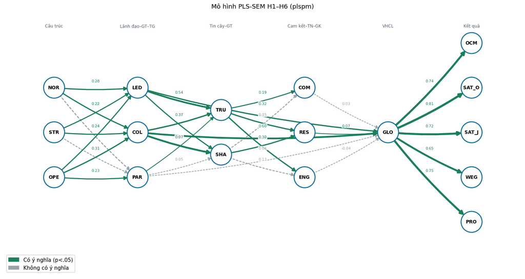

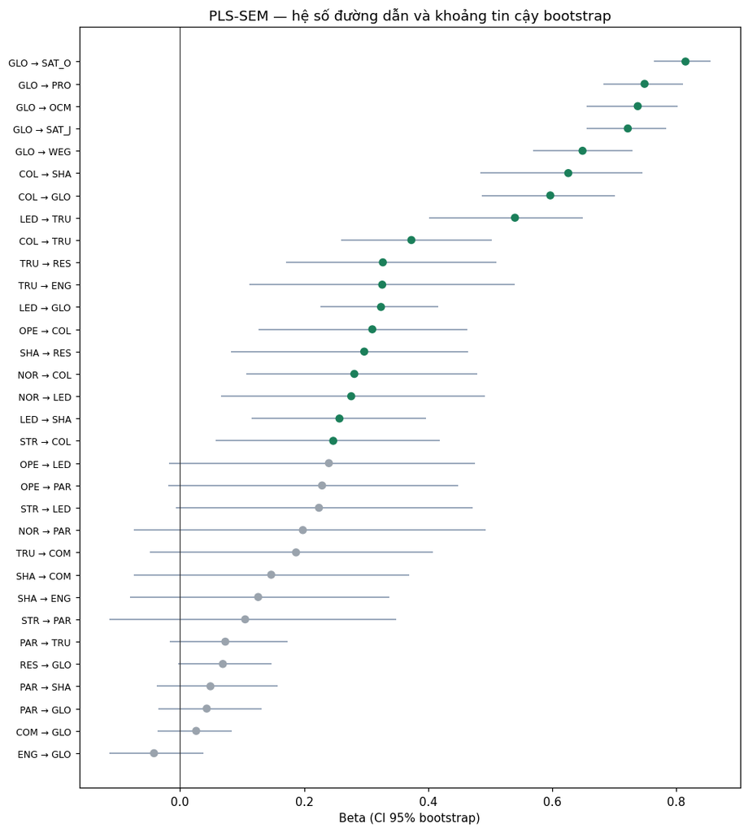

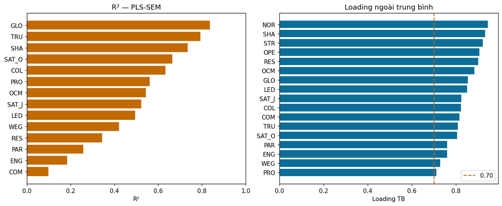

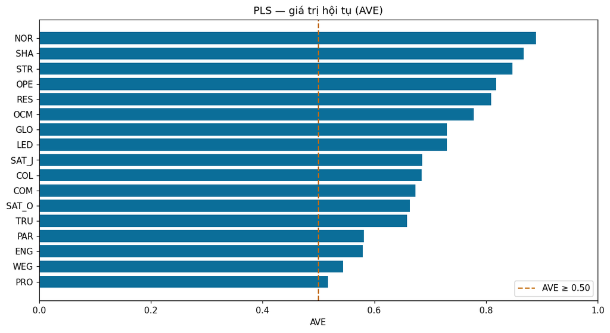

```python
# === VISUALIZATION CELL ===
# Helper vẽ sơ đồ path H1–H6 (dùng lại cho semopy & PLS)
import networkx as nx
import matplotlib.patches as mpatches

_LAYERS = [
    ['NOR', 'STR', 'OPE'],
    ['LED', 'COL', 'PAR'],
    ['TRU', 'SHA'],
    ['COM', 'RES', 'ENG'],
    ['GLO'],
    ['OCM', 'SAT_O', 'SAT_J', 'WEG', 'PRO'],
]
_LAYER_CAP = ['Cấu trúc', 'Lãnh đạo–GT–TG', 'Tin cậy–GT', 'Cam kết–TN–GK', 'VHCL', 'Kết quả']
_C_OK, _C_NS, _C_ACC, _C_BG = '#1b7f5a', '#9aa3ad', '#0b6e99', '#f7f9fb'

def ve_so_do_path(path_df, beta_col, from_col, to_col, sig_col, title, outfile):
    G = nx.DiGraph(); pos = {}
    for xi, layer in enumerate(_LAYERS):
        n = len(layer)
        for yi, node in enumerate(layer):
            G.add_node(node); pos[node] = (xi, (n - 1) / 2 - yi)
    edges = []
    for _, r in path_df.iterrows():
        u, v = r[from_col], r[to_col]
        if u not in G or v not in G: continue
        sig = str(r[sig_col]); is_sig = 'Có' in sig
        edges.append((u, v, float(r[beta_col]), is_sig))
    fig, ax = plt.subplots(figsize=(14, 7.5)); ax.set_facecolor(_C_BG)
    nx.draw_networkx_nodes(G, pos, node_size=1600, node_color='white', edgecolors=_C_ACC, linewidths=1.8, ax=ax)
    nx.draw_networkx_labels(G, pos, font_size=9, font_weight='bold', ax=ax)
    for u, v, beta, is_sig in edges:
        color = _C_OK if is_sig else _C_NS
        nx.draw_networkx_edges(G, pos, edgelist=[(u, v)], width=1.2 + 3.5 * abs(beta),
            edge_color=color, arrows=True, arrowsize=14, connectionstyle='arc3,rad=0.05',
            style='solid' if is_sig else (0, (2, 2)), ax=ax, min_source_margin=18, min_target_margin=18)
        x1, y1 = pos[u]; x2, y2 = pos[v]
        ax.text((x1 + x2) / 2, (y1 + y2) / 2 + 0.12, f'{beta:.2f}', fontsize=7, color=color, ha='center',
                bbox=dict(boxstyle='round,pad=0.15', fc='white', ec='none', alpha=0.75))
    for xi, cap in enumerate(_LAYER_CAP):
        ax.text(xi, 2.35, cap, ha='center', fontsize=8, color='#52606d')
    ax.set_title(title); ax.axis('off'); ax.set_xlim(-0.6, 5.6); ax.set_ylim(-3.2, 2.7)
    ax.legend(handles=[mpatches.Patch(color=_C_OK, label='Có ý nghĩa (p<.05)'),
                       mpatches.Patch(color=_C_NS, label='Không có ý nghĩa')], loc='lower left')
    plt.tight_layout(); plt.savefig(f'{OUT}/{outfile}', bbox_inches='tight'); plt.show()


ve_so_do_path(out_paths, 'Beta', 'Biến độc lập', 'Biến phụ thuộc', 'Kết luận',
              'Mô hình PLS-SEM H1–H6 (plspm)', 'hinh_mo_hinh_path_pls.png')

fig, ax = plt.subplots(figsize=(9, 10))
bf = boot_summary.copy()
bf['label'] = bf['Biến độc lập'] + ' → ' + bf['Biến phụ thuộc']
bf = bf.sort_values('Beta'); y = np.arange(len(bf))
cols = ['#1b7f5a' if s == 'Có' else '#9aa3ad' for s in bf['Ý nghĩa (CI không chứa 0)']]
ax.hlines(y, bf['CI2.5%'], bf['CI97.5%'], color='#94a3b8', lw=1.2)
ax.scatter(bf['Beta'], y, c=cols, s=35, zorder=3)
ax.axvline(0, color='#333', lw=.8)
ax.set_yticks(y); ax.set_yticklabels(bf['label'], fontsize=8)
ax.set_xlabel('Beta (CI 95% bootstrap)')
ax.set_title('PLS-SEM — hệ số đường dẫn và khoảng tin cậy bootstrap')
plt.tight_layout(); plt.savefig(f'{OUT}/hinh_pls_path_ci.png', bbox_inches='tight'); plt.show()

fig, axes = plt.subplots(1, 2, figsize=(12, 5))
ordp = r2_pls.sort_values('R2')
axes[0].barh(ordp.index.astype(str), ordp['R2'], color='#c26a00')
axes[0].set_xlim(0, 1); axes[0].set_xlabel('R²'); axes[0].set_title('R² — PLS-SEM')
g = outer_out.groupby('Khái niệm')['loading'].mean().sort_values()
axes[1].barh(g.index.astype(str), g.values, color='#0b6e99')
axes[1].axvline(.70, color='#c26a00', ls='--', label='0.70')
axes[1].set_xlabel('Loading TB'); axes[1].set_title('Loading ngoài trung bình'); axes[1].legend(loc='lower right')
plt.tight_layout(); plt.savefig(f'{OUT}/hinh_r2_pls.png', bbox_inches='tight'); plt.show()

fig, ax = plt.subplots(figsize=(10, 5.5))
m = meas.sort_values('ave')
ax.barh(m.index.astype(str), m['ave'], color='#0b6e99')
ax.axvline(.50, color='#c26a00', ls='--', label='AVE ≥ 0.50')
ax.set_xlim(0, 1); ax.set_xlabel('AVE'); ax.set_title('PLS — giá trị hội tụ (AVE)'); ax.legend(loc='lower right')
plt.tight_layout(); plt.savefig(f'{OUT}/hinh_pls_ave.png', bbox_inches='tight'); plt.show()
```

## 12. Phân tích vai trò trung gian (bootstrap 2.000 lần)

Kiểm định GLO (VHCL) làm trung gian giữa các yếu tố tâm lý – tổ chức và kết quả.

```python
med_rows = []
for x in ['COM','RES','ENG','LED','COL','PAR']:
    for y in ['OCM','SAT_J','WEG','PRO','SAT_O']:
        r = pg.mediation_analysis(data=df, x=x+'_c', m='GLO_c', y=y+'_c', n_boot=2000, seed=42)
        ind = r[r['path'] == 'Indirect'].iloc[0]
        dirp = r[r['path'] == 'Direct'].iloc[0]
        med_rows.append({'X': x, 'M': 'GLO', 'Y': y,
            'Gián tiếp (ab)': round(ind['coef'], 3), 'CI95': f"[{ind['CI2.5']:.3f}; {ind['CI97.5']:.3f}]",
            'Ý nghĩa gián tiếp': 'Có' if ind['sig'] == 'Yes' else 'Không',
            'Trực tiếp (c\')': round(dirp['coef'], 3), 'p trực tiếp': round(dirp['pval'], 4),
            'Loại trung gian': ('Toàn phần' if (ind['sig'] == 'Yes' and dirp['pval'] >= .05)
                                 else ('Một phần' if ind['sig'] == 'Yes' else '—'))})
med_df = pd.DataFrame(med_rows)
med_df.to_csv(f'{OUT}/bang_trung_gian.csv', index=False, encoding='utf-8-sig')
SUMMARY['mediation'] = med_df.to_dict('records')
med_df
```

|  | X | M | Y | Gián tiếp (ab) | CI95 | Ý nghĩa gián tiếp | Trực tiếp (c') | p trực tiếp | Loại trung gian |
| --- | --- | --- | --- | --- | --- | --- | --- | --- | --- |
| 0 | COM | GLO | OCM | 0.331 | [0.199; 0.473] | Có | 0.185 | 0.0067 | Một phần |
| 1 | COM | GLO | SAT_J | 0.225 | [0.137; 0.316] | Có | -0.010 | 0.8307 | Toàn phần |
| 2 | COM | GLO | WEG | 0.196 | [0.118; 0.292] | Có | 0.334 | 0.0000 | Một phần |
| 3 | COM | GLO | PRO | 0.207 | [0.119; 0.311] | Có | 0.185 | 0.0004 | Một phần |
| 4 | COM | GLO | SAT_O | 0.296 | [0.177; 0.414] | Có | -0.061 | 0.1776 | Toàn phần |
| 5 | RES | GLO | OCM | 0.407 | [0.287; 0.539] | Có | 0.225 | 0.0001 | Một phần |
| 6 | RES | GLO | SAT_J | 0.273 | [0.204; 0.348] | Có | 0.115 | 0.0033 | Một phần |
| 7 | RES | GLO | WEG | 0.283 | [0.200; 0.376] | Có | 0.089 | 0.0652 | Toàn phần |
| 8 | RES | GLO | PRO | 0.301 | [0.211; 0.403] | Có | 0.030 | 0.4967 | Toàn phần |
| 9 | RES | GLO | SAT_O | 0.369 | [0.282; 0.456] | Có | 0.106 | 0.0043 | Một phần |
| 10 | ENG | GLO | OCM | 0.424 | [0.294; 0.563] | Có | 0.399 | 0.0000 | Một phần |
| 11 | ENG | GLO | SAT_J | 0.297 | [0.220; 0.383] | Có | 0.120 | 0.0172 | Một phần |
| 12 | ENG | GLO | WEG | 0.236 | [0.169; 0.322] | Có | 0.492 | 0.0000 | Một phần |
| 13 | ENG | GLO | PRO | 0.267 | [0.179; 0.372] | Có | 0.294 | 0.0000 | Một phần |
| 14 | ENG | GLO | SAT_O | 0.419 | [0.310; 0.534] | Có | -0.045 | 0.3446 | Toàn phần |
| 15 | LED | GLO | OCM | 0.378 | [0.249; 0.517] | Có | 0.326 | 0.0000 | Một phần |
| 16 | LED | GLO | SAT_J | 0.249 | [0.183; 0.324] | Có | 0.203 | 0.0000 | Một phần |
| 17 | LED | GLO | WEG | 0.281 | [0.179; 0.399] | Có | 0.153 | 0.0073 | Một phần |
| 18 | LED | GLO | PRO | 0.343 | [0.225; 0.441] | Có | 0.052 | 0.3133 | Toàn phần |
| 19 | LED | GLO | SAT_O | 0.466 | [0.388; 0.552] | Có | 0.035 | 0.4219 | Toàn phần |
| 20 | COL | GLO | OCM | 0.612 | [0.400; 0.816] | Có | 0.125 | 0.1648 | Toàn phần |
| 21 | COL | GLO | SAT_J | 0.301 | [0.209; 0.402] | Có | 0.208 | 0.0007 | Một phần |
| 22 | COL | GLO | WEG | 0.333 | [0.187; 0.475] | Có | 0.166 | 0.0294 | Một phần |
| 23 | COL | GLO | PRO | 0.278 | [0.138; 0.414] | Có | 0.237 | 0.0005 | Một phần |
| 24 | COL | GLO | SAT_O | 0.390 | [0.293; 0.494] | Có | 0.271 | 0.0000 | Một phần |
| 25 | PAR | GLO | OCM | 0.463 | [0.334; 0.611] | Có | 0.385 | 0.0000 | Một phần |
| 26 | PAR | GLO | SAT_J | 0.346 | [0.276; 0.418] | Có | 0.120 | 0.0120 | Một phần |
| 27 | PAR | GLO | WEG | 0.230 | [0.154; 0.321] | Có | 0.444 | 0.0000 | Một phần |
| 28 | PAR | GLO | PRO | 0.289 | [0.206; 0.380] | Có | 0.273 | 0.0000 | Một phần |
| 29 | PAR | GLO | SAT_O | 0.509 | [0.415; 0.612] | Có | -0.010 | 0.8220 | Toàn phần |

### Trực quan hóa — trung gian qua GLO

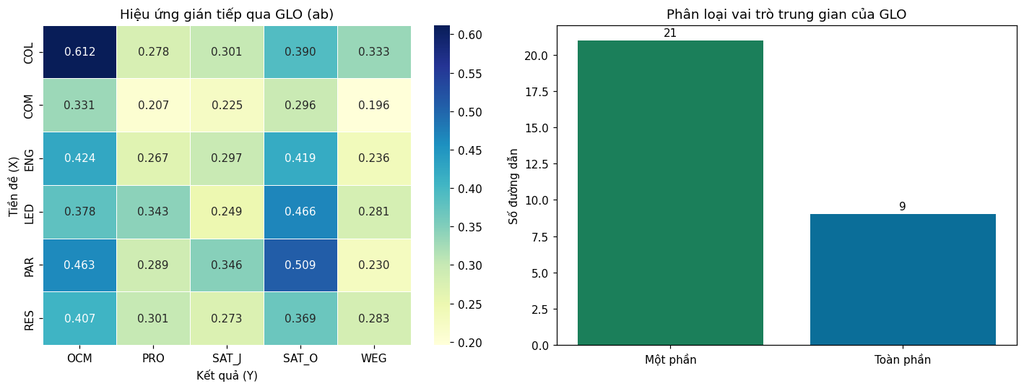

```python
# === VISUALIZATION CELL ===
fig, axes = plt.subplots(1, 2, figsize=(13, 5))
pivot = med_df.pivot(index='X', columns='Y', values='Gián tiếp (ab)')
sns.heatmap(pivot, annot=True, fmt='.3f', cmap='YlGnBu', ax=axes[0], linewidths=.4, linecolor='white')
axes[0].set_title('Hiệu ứng gián tiếp qua GLO (ab)')
axes[0].set_xlabel('Kết quả (Y)'); axes[0].set_ylabel('Tiền đề (X)')
vc = med_df['Loại trung gian'].value_counts()
axes[1].bar(vc.index.astype(str), vc.values, color=['#1b7f5a', '#0b6e99', '#9aa3ad'][:len(vc)])
axes[1].set_ylabel('Số đường dẫn'); axes[1].set_title('Phân loại vai trò trung gian của GLO')
for i, v in enumerate(vc.values):
    axes[1].text(i, v + .3, str(v), ha='center')
plt.tight_layout(); plt.savefig(f'{OUT}/hinh_trung_gian_heatmap.png', bbox_inches='tight'); plt.show()
```

## 13. Giá trị nền tảng của VHCL (SHA3 – SHA4, câu hỏi nhiều lựa chọn)

SHA3: các giá trị được lựa chọn là quan trọng; SHA4: xếp hạng 5 giá trị quan trọng nhất.

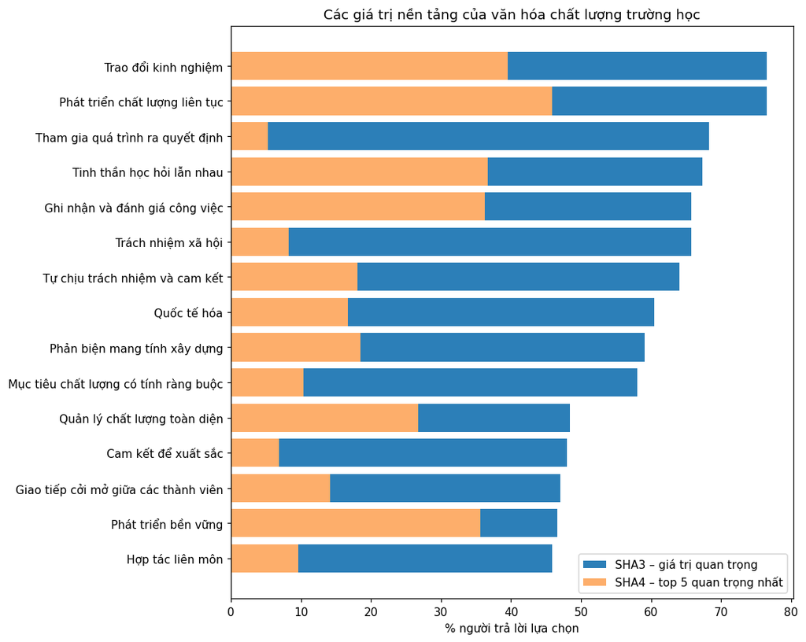

|  | Giá trị | SHA3: lượt chọn | SHA3: % | SHA4: lượt chọn top-5 | SHA4: % |
| --- | --- | --- | --- | --- | --- |
| 0 | Trao đổi kinh nghiệm | 215 | 76.5 | 111 | 39.5 |
| 1 | Phát triển chất lượng liên tục | 215 | 76.5 | 129 | 45.9 |
| 2 | Tham gia quá trình ra quyết định | 192 | 68.3 | 15 | 5.3 |
| 3 | Tinh thần học hỏi lẫn nhau | 189 | 67.3 | 103 | 36.7 |
| 4 | Ghi nhận và đánh giá công việc | 185 | 65.8 | 102 | 36.3 |
| 5 | Trách nhiệm xã hội | 185 | 65.8 | 23 | 8.2 |
| 6 | Tự chịu trách nhiệm và cam kết | 180 | 64.1 | 51 | 18.1 |
| 7 | Quốc tế hóa | 170 | 60.5 | 47 | 16.7 |
| 8 | Phản biện mang tính xây dựng | 166 | 59.1 | 52 | 18.5 |
| 9 | Mục tiêu chất lượng có tính ràng buộc | 163 | 58.0 | 29 | 10.3 |
| 10 | Quản lý chất lượng toàn diện | 136 | 48.4 | 75 | 26.7 |
| 11 | Cam kết để xuất sắc | 135 | 48.0 | 19 | 6.8 |
| 12 | Giao tiếp cởi mở giữa các thành viên | 132 | 47.0 | 40 | 14.2 |
| 13 | Phát triển bền vững | 131 | 46.6 | 100 | 35.6 |
| 14 | Hợp tác liên môn | 129 | 45.9 | 27 | 9.6 |

```python
VALUES = ['Trao đổi kinh nghiệm','Phát triển chất lượng liên tục','Tham gia quá trình ra quyết định',
 'Sáng tạo trong cách tiếp cận','Chính sách chất lượng rõ ràng','Tự phản tư','Hợp tác với đối tác bên ngoài',
 'Tinh thần học hỏi lẫn nhau','Giao tiếp minh bạch','Quản lý chất lượng toàn diện','Mục tiêu chất lượng có tính ràng buộc',
 'Hiểu biết chung về chất lượng','Hợp tác dựa trên sự tin tưởng','Trách nhiệm xã hội','Đa dạng','Hợp tác liên môn',
 'Phát triển bền vững','Tự chịu trách nhiệm và cam kết','Tự do trong phương pháp giảng dạy','Cam kết để xuất sắc',
 'Giao tiếp cởi mở giữa các thành viên','Quốc tế hóa','Ghi nhận và đánh giá công việc','Phản biện mang tính xây dựng']
sha3_cols = [f'SHA3_{i:02d}' for i in range(1, 25)]
sha4_cols = [f'SHA4_{i:02d}' for i in range(1, 25)]
df[sha4_cols] = df[sha4_cols].apply(lambda c: pd.to_numeric(c.astype(str).str.extract(r'(\d+)')[0], errors='coerce').fillna(0).astype(int))
sha3 = df[sha3_cols].sum()
sha4_sel = (df[sha4_cols] > 0).sum()
sha = pd.DataFrame({'Giá trị': VALUES, 'SHA3: lượt chọn': sha3.values,
                    'SHA3: %': (100*sha3.values/len(df)).round(1),
                    'SHA4: lượt chọn top-5': sha4_sel.values,
                    'SHA4: %': (100*sha4_sel.values/len(df)).round(1)})
sha = sha.sort_values('SHA3: lượt chọn', ascending=False).reset_index(drop=True)
sha.to_csv(f'{OUT}/bang_gia_tri_VHCL.csv', index=False, encoding='utf-8-sig')
SUMMARY['values_top10'] = sha.head(10).to_dict('records')
plt.figure(figsize=(10, 8))
top = sha.head(15).iloc[::-1]
plt.barh(top['Giá trị'], top['SHA3: %'], color='#2c7fb8', label='SHA3 – giá trị quan trọng')
plt.barh(top['Giá trị'], top['SHA4: %'], color='#fdae6b', label='SHA4 – top 5 quan trọng nhất')
plt.xlabel('% người trả lời lựa chọn'); plt.legend()
plt.title('Các giá trị nền tảng của văn hóa chất lượng trường học')
plt.tight_layout(); plt.savefig(f'{OUT}/hinh_gia_tri_VHCL.png', bbox_inches='tight'); plt.show()
sha.head(15)
```

## 14. Tổng hợp kết quả kiểm định giả thuyết (semopy + PLS-SEM)

```python
def path_sig(dep, ind):
    r = [p for p in SUMMARY['paths'] if p['Biến phụ thuộc'] == dep and p['Biến độc lập'] == ind]
    return r[0] if r else None

hyp = {
 'H1': [(d, i) for d in ['LED','COL','PAR'] for i in ['NOR','STR','OPE']],
 'H2': [(d, i) for d in ['TRU','SHA'] for i in ['LED','COL','PAR']],
 'H3': [(d, i) for d in ['COM','RES','ENG'] for i in ['TRU','SHA']],
 'H4': [('GLO', i) for i in ['COM','RES','ENG']],
 'H5': [(d, 'GLO') for d in ['OCM','SAT_O','SAT_J','WEG','PRO']],
 'H6': [('GLO', i) for i in ['LED','COL','PAR']],
}
rows = []
for h, pairs in hyp.items():
    n_sig = sum(1 for d, i in pairs if path_sig(d, i) and path_sig(d, i)['Kết luận'] == 'Có ý nghĩa')
    rows.append({'Giả thuyết': h, 'Số đường dẫn': len(pairs), 'Có ý nghĩa (p<.05)': n_sig,
                 'Kết luận (semopy)': 'Chấp nhận' if n_sig == len(pairs) else ('Chấp nhận một phần' if n_sig > 0 else 'Bác bỏ')})
hyp_df = pd.DataFrame(rows)
if 'pls_hypotheses' in SUMMARY:
    pls_map = {r['Giả thuyết']: r['Kết luận PLS'] for r in SUMMARY['pls_hypotheses']}
    hyp_df['Kết luận (PLS-SEM)'] = hyp_df['Giả thuyết'].map(pls_map)
hyp_df.to_csv(f'{OUT}/bang_ket_luan_gia_thuyet.csv', index=False, encoding='utf-8-sig')
SUMMARY['hypotheses'] = hyp_df.to_dict('records')
with open(f'{OUT}/summary.json', 'w', encoding='utf-8') as f:
    json.dump(SUMMARY, f, ensure_ascii=False, indent=1, default=str)
print('Đã lưu toàn bộ kết quả vào thư mục:', OUT)
hyp_df
```

```
Đã lưu toàn bộ kết quả vào thư mục: ket_qua
```

|  | Giả thuyết | Số đường dẫn | Có ý nghĩa (p<.05) | Kết luận (semopy) | Kết luận (PLS-SEM) |
| --- | --- | --- | --- | --- | --- |
| 0 | H1 | 9 | 7 | Chấp nhận một phần | Chấp nhận một phần |
| 1 | H2 | 6 | 4 | Chấp nhận một phần | Chấp nhận một phần |
| 2 | H3 | 6 | 3 | Chấp nhận một phần | Chấp nhận một phần |
| 3 | H4 | 3 | 1 | Chấp nhận một phần | Chấp nhận một phần |
| 4 | H5 | 5 | 5 | Chấp nhận | Chấp nhận |
| 5 | H6 | 3 | 2 | Chấp nhận một phần | Chấp nhận một phần |

### Trực quan hóa — tổng hợp giả thuyết

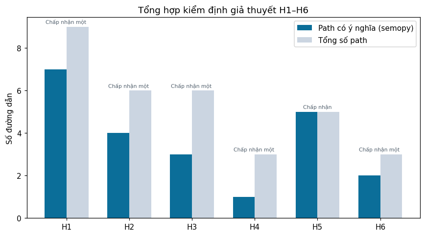

```python
# === VISUALIZATION CELL ===
fig, ax = plt.subplots(figsize=(8, 4.5))
x = np.arange(len(hyp_df)); w = .35
ax.bar(x - w/2, hyp_df['Có ý nghĩa (p<.05)'], w, color='#0b6e99', label='Path có ý nghĩa (semopy)')
ax.bar(x + w/2, hyp_df['Số đường dẫn'], w, color='#cbd5e1', label='Tổng số path')
ax.set_xticks(x); ax.set_xticklabels(hyp_df['Giả thuyết'])
ax.set_ylabel('Số đường dẫn'); ax.set_title('Tổng hợp kiểm định giả thuyết H1–H6'); ax.legend()
if 'Kết luận (PLS-SEM)' in hyp_df.columns:
    for i, row in hyp_df.iterrows():
        ax.text(i, row['Số đường dẫn'] + .15, str(row['Kết luận (PLS-SEM)'])[:14],
                ha='center', fontsize=7, color='#52606d')
plt.tight_layout(); plt.savefig(f'{OUT}/hinh_tong_hop_gia_thuyet.png', bbox_inches='tight'); plt.show()
```